# 智能制造系统设计 · 第 10 讲：工程伦理（三）与综合

刘训臣

山东科技大学 机械电子工程学院

# 第〇部分 · 课程介绍与本讲定位

- 四个内容块：技术的社会意义与工程国际化 → AI 伦理与治理 → 智能设计应用 → 前沿、课程设计与总复习
- 本讲是全课程伦理主线的收口：第 8、9 讲给准则与框架，本讲给一般理论、国际化视野与 AI 伦理增量
- 本讲同时承担两项综合任务：**课程设计指导**（技术方案 + 伦理与社会影响分析）与**全课程总复习**
- 一条主线：**技术讲到哪里，伦理与社会问题就分析到哪里；最后把分析写成可操作的三步框架**

## 第 10 讲：教学内容与主线（一）

**内容块 1 · 技术的社会意义与工程国际化**

- 技术发展内嵌于社会：科技进步是源动力、社会价值观选择技术路线、人本主义决定技术标准
- 科技与社会政策：隐私（信息／财产／选择隐私、Privacy Act 1974）、知识产权（安妮法案 1710）
- 工程国际标准：Washington / Sydney / Dublin Accord、FEANI、ISO
- 国际化职业守则：FEIAP、JSPE、CEC、WFEO；国际化公司的六类伦理陷阱

**内容块 2 · AI 伦理与智能制造责任**

- 风险三维度：算法（安全、可解释性、决策困境）、数据（隐私、敏感信息）、应用（歧视、滥用）
- 治理框架：人类根本利益与责任两条原则、八项评估指标、五步风险管理流程
- 自动化安全底线与人机协作责任划分

## 第 10 讲：教学内容与主线（二）

**内容块 3 · 智能设计应用**

- 机器视觉检测：系统组成、相机与镜头选型、光源与图像采集、缺陷检测与尺寸测量
- 三个落地案例：羊只姿态检测（YOLOv5）、图神经网络预测裂纹（GAT）、振源智能识别（盲源分离）
- 算法落地的工程约束：数据来源、实时性、可解释、维护与责任

**内容块 4 · 前沿、课程设计与总复习**

- 前沿：工业互联网与数字孪生、生成式 AI、协作机器人、柔性制造与个性化定制
- 课程设计：技术方案五要素 + 伦理与社会影响分析三步框架
- 总复习：设计基础、企业系统与 8D、伦理与 AI 伦理三大块的要点与题型

## 教学进度 · 10 次课全览

| 次 | 模块 | 主题 |
| --- | --- | --- |
| 1 | 导论与 3.1 | 课程导论、工程与社会与质量工程（一）：国家战略、工程的社会属性、质量管理基础 |
| 2 | 3.1 | 质量工程（二）与质量工具：五大工具 APQP／FMEA／MSA／SPC／PPAP、CPK、QC 七大手法 |
| 3 | 3.2 | 工业工程与精益生产（＋实验 2 课时：线性规划与工业工程例子） |
| 4 | 3.3、3.4 | 安全工程与环保工程：海因里希法则、事故树 FTA、风险评估、三废治理、双碳 |
| 5 | 3.5、3.6 | 成本管理与人力资源：成本构成、投资回收期、NPV／IRR、质量成本、人才与激励 |
| 6 | 4.1～4.3 | 企业信息系统（一）：ERP、MES、PLM 与系统集成全景 |
| 7 | 4、6 | 企业信息系统（二）与 8D：CRM／WMS／APS，8D 八步与软件开发流程 |
| 8 | 工程伦理（一） | 工程事故与伦理准则：凯悦酒店、NSPE 准则、伦理决策框架 |
| 9 | 工程伦理（二） | 风险、安全与责任，工程师与组织：责任判定、组织文化与信任 |
| **10** | **伦理（三）与综合** | **技术的社会意义、国际化、AI 伦理；智能设计应用、前沿、课程设计与总复习** |

## 本讲在课程中的位置

**伦理专题的分工：6 课时（第 1、8、9、10 讲）**

| 讲（伦理课时） | 主题 | 核心产出 |
| --- | --- | --- |
| 1（1） | 工程与社会导论 | 工程定义、社会实验、隐含契约 |
| 8（2） | 事故与伦理准则 | NSPE 准则、三种决策框架 |
| 9（2） | 风险、责任与组织 | 责任判定、组织模糊化、信任 |
| 10（1） | 技术社会、国际化、AI 伦理 | 一般理论、国际标准、**三步框架** |

- 四讲递进：出了事怎么办（第 8 讲）→ 在组织中怎么负责（第 9 讲）→ 技术本身该怎么选（第 10 讲）
- 6 课时＝第 1 讲 1 ＋ 第 8 讲 2 ＋ 第 9 讲 2 ＋ 第 10 讲 1，合起来就是课程设计要求的**伦理与社会影响分析**章

## 本讲的伦理与社会落点

- **落点 1**：技术不是价值中立的——社会价值观选择技术路线，工程师的选择本身包含价值判断
- **落点 2**：国际化不是“标准更高就行”——同一套设备在不同国家面对不同排放与劳工标准，工程师必须给出可辩护的立场
- **落点 3**：AI 的伦理风险是系统性的——数据偏见会沿模型、产线、决策链条放大到成千上万人
- **落点 4**：智能检测的漏检代价由谁承担——算法供应商、工厂、操作者与最终用户之间的责任必须写清
- 汇总：**利益相关方与影响分析 → 伦理问题识别与定位 → 伦理决策与辩护**

> 一句话：伦理不是最后附加的一章，而是设计决策的一个维度。

## 本讲 90 分钟怎么安排：六块时间账

> **六块 6＋24＋22＋18＋12＋8＝90 分钟；两个伦理块占 46 分钟，是全场重心。**

| 序 | 时间块 | 讲什么 | 分钟 |
| --- | --- | --- | --- |
| 0 | 开场与回顾 | 六问、目标、路线图 | 6 |
| 1 | 技术与社会 | 技术评价、隐私、国际化 | 24 |
| 2 | AI 伦理 | 三维度、八指标、五步治理 | 22 |
| 3 | 智能设计 | 选型、YOLOv5、GNN、振源 | 18 |
| 4 | 前沿与课设 | 数字孪生、路线图、五要素 | 12 |
| 5 | 总复习与收尾 | 四类题、小结、作业 | 8 |

- 两个伦理块合计 46 分钟，是全场重心；智能设计 18 分钟只讲“能不能落地”
- 158 页是讲义总量，不是课时量：84 分钟平均每页约 32 秒，只讲判据与案例
- 例题、讨论与总复习索引留给课后模拟，课堂只点方法与易错点
- 先压：数字孪生技术细节、国际标准逐条、AI 报告原文
- 不能压：技术内嵌三个方向、跨文化底线、AI 责任链、课设评分

## 第 9 讲回顾与检查：六个问题

> **六问各 30 秒：答不出的那一条，就是本讲要接的那一条。**

| 概念 | 一句话答案 | 今天怎么接 |
| --- | --- | --- |
| ① 风险三读 | 期望值、FAR、F-N 曲线：三种读法 | 技术评估不能只看均值 |
| ② 事故责任 | 应尽未尽的注意义务；四问定性质 | 算法事故也要过四问 |
| ③ 群体思维 | 为一致牺牲批判；八症状 | 模型评审为何“一致通过” |
| ④ 服从实验 | 米尔格拉姆：26/40 到 450 V；四机制 | “我只是按输出签字” |
| ⑤ 吹哨 | 明显危害、内部走尽、公开止损 | 算法伤害的举报渠道 |
| ⑥ 安全文化 | 报告、公正、学习三支柱 | 模型留痕与无责报告 |

- 六问分三组：①② 算与判，③④ 组织与服从，⑤⑥ 制度与文化
- 抽查 4 分钟：合上讲义写关键词，随机点两人，答不出不扣分
- 米尔格拉姆四机制：责任转移、渐进承诺、角色服从、程序合法性
- 最易错：$R=\sum_i p_i c_i$ 只是期望值一读，不能代替 FAR 与 $F_N$ 曲线
- 一句提醒：第 9 讲问“为什么做不到”，本讲追问“技术本身该不该这样选”

## 本讲学习目标与能力清单：析、判、评、设

> **四条能力＝四个动作：析社会影响、判跨文化、评 AI 伦理、设课程设计。**

| 能力 | 具体内容（本讲落点） | 验收标准（可检查） |
| --- | --- | --- |
| 析社会影响 | 技术内嵌、技术决定论、批判态度 | 列 3 个利益相关方、2 个不可逆影响 |
| 判跨文化 | 三大协定、六类陷阱、中间道路 | 写“可让渡／不可让渡”清单各 3 条 |
| 评 AI 伦理 | 三维度、两原则八指标、五步流程 | 填八项指标表，指出 2 个高风险项 |
| 设课程设计 | 技术五要素、伦理章三步框架 | 交伦理章提纲：名单／问题／取舍／辩护 |

- 四个动词：析、判、评、设；不要求背伦理学史与人名年代
- 每项能力配一次课堂动作与一次作业落点，验收写成能交的东西
- 与前两讲分工：第 8 讲会判、第 9 讲会算会写，本讲会析会评
- 最低线：四项都能在课程设计报告里找到对应段落
- 提醒：这张表就是课程设计评分表的另一种写法（建议权重：技术 40／数据 20／伦理 20／报告答辩 20）

## 伦理专题三讲收官与全课程回顾

> **三讲不是三块知识，而是一条能力链：判该不该 → 判谁负责 → 判技术该不该这样选。**

| 讲 | 交给你的一件工具 | 收官时仍未解的问题 |
| --- | --- | --- |
| 第 8 讲 | 事故链、NSPE 准则、三框架 | 知道该说“不”，压力下仍说不出口 |
| 第 9 讲 | 风险三读法、判定四问、文化八条 | 能判定责任，技术路线的社会后果未碰 |
| 第 10 讲 | 三步框架、跨文化底线、AI 治理 | 没有标准答案，底线要自己论证 |

- 三讲各留一件工具：事故链、风险三读法、三步框架，都要能当场用
- 全课程三段：工程与社会、设计与质量（1–2 讲）→ 效率、安全、成本、系统（3–7 讲）→ 判断与综合（8–10 讲）
- 伦理线共 6 课时：第 1 讲 1 ＋ 第 8 讲 2 ＋ 第 9 讲 2 ＋ 第 10 讲 1，不是附加章
- 前 7 讲教“把事做成”，后 3 讲追问“该不该这样做”；课程设计把两问合到一张图纸上
- 一句话：伦理三讲不是课程的尾巴，而是把前七讲的技术选择重新照亮

## 考试视角：本讲与期末总复习的关系

> **本讲一面收束前 9 讲，一面交付智能设计这块可考内容。**

| 本讲资源 | 可直接用于 | 总复习怎么用 |
| --- | --- | --- |
| 第一、二部分 | 论述题的框架与判据 | 技术选择、AI 责任各写一句 |
| 第三部分 | 简答：图像处理 5 方法 | 背“预处理→增强→分割→特征” |
| 第五部分 | 计算、简答、论述三种题型 | 限时做，当模拟卷 |
| 第四、六部分 | 总复习索引、小结与作业 | 查漏、收口、定计划 |

- 六卷结构：单选 30 ＋ 简答 30 ＋ 论述 30 ＋ 计算 10；2021 A 卷写作“分析简答 30 ＋ 论述与计算 40”
- 图像处理 5 方法是 2020B／2021B／2022B 简答；图论矩阵是 2022A 第三题
- 本讲的用法是“复习枢纽”：把前 9 讲判据收进四类题，再补智能设计
- 复习顺序：例题 → 一套真题 → 错题清单 → 回讲义；不要从第一页开始翻
- 提醒：AI 伦理不押题；论述里写清算法责任链，答案更完整

## 本讲路线图与课前准备

> **主线：技术嵌入社会 → 评 AI 风险 → 算法落地 → 收进课程设计与考试。**

| 块 | 分钟 | 入口问题 | 出口 |
| --- | --- | --- | --- |
| 〇 开场 | 6 | 第 9 讲留下什么 | 六问过关、目标清楚 |
| 一 技术社会 | 24 | 技术是否价值中立 | 三个方向、一个国际判据 |
| 二 AI 伦理 | 22 | 算法错了谁负责 | 八项指标、责任链 |
| 三 智能设计 | 18 | 模型能不能落地 | 选型算得清、六条约束 |
| 四 前沿课设 | 12 | 趋势怎么变成方案 | 五要素与评分权重 |
| 五 总复习 | 8 | 四类题怎么答 | 有模板、作业与答辩清楚 |

- 课前读：Harris 第 4、8、9 章（技术与社会、工程师与环境、全球背景）
- 配套：2020 课件 4、7、8 与 AI 伦理风险分析报告；必带讲义、计算器、课程设计提纲
- 预习：你课题的技术路线是谁选的？换一个国家或用户，哪条底线不能让？
- 纪律：案例的事实链与判定会进论述题，跟事实链、不抄 PPT

## 推导留给 AI：课程介绍与本讲定位（汇总）

**推导留给 AI**（先自己推，再让 AI 校验，最后交完整推导）

- ① 为什么这门课要用三次课讲工程伦理？请用前面任意一个技术工具（FMEA、8D、SPC、MES）说明“技术决策如何变成社会后果”。
- ② 把本课程 10 个主题按“技术—管理—伦理”三类重新归类，并说明三类之间的依赖顺序。
- ③ 本讲四个内容块按“伦理理论 → AI 伦理 → 智能设计 → 前沿与综合”排序，如果调换顺序会失去什么？
- ④ 如果只能带走一条本课程的主线，你会选哪一条？给出支持它的三个技术事实。

## 产教融合 · 本讲企业真题：AI 质检的漏检、隐私与课程设计

> **企业场景：**企业齿轮视觉检测漏检率约 4%、目标≤1%、单件节拍≤2 s；采集员工操作影像用于训练，边界未写清。

| 企业真实问题 | 本讲工具 | 学生产出 |
| --- | --- | --- |
| 模型漏检、数据标注质量与员工影像隐私；课程设计要交伦理分析章 | AI 伦理四问、三步分析框架、课程设计评分标准 | 伦理分析章＋课程设计（企业零件缺陷智能评测） |

- **教案对应：**第五章 设计方法、第六章 设计过程、课程设计；**企业参与：**质量部提供脱敏缺陷图像与验收指标，企业导师参与答辩
- **验收：**四类影响（安全、隐私、公平、环境）均有证据；备选方案与辩护完整；课程设计能落地。

# 第一部分 · 技术的社会意义与工程国际化

- 技术的社会属性：工程作为社会实验，技术发展内嵌于社会发展
- 技术评价：决定论、乐观主义、悲观主义与工程师的批判态度
- 技术的社会政策：隐私、知识产权与环境责任
- 工程国际化与职业能力：三大认证协定、国际守则、教育认证、注册工程师

## 技术内嵌于社会：一个定义、三个类比与一对箭头

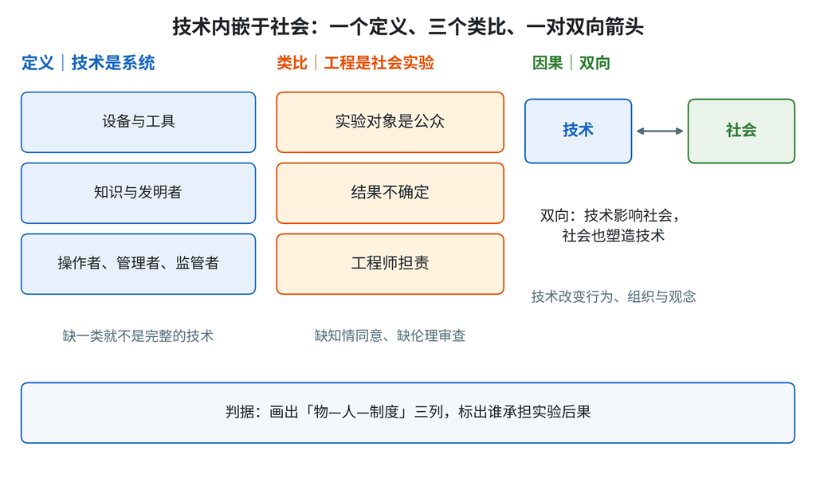

- **是什么**：技术不是工具清单，是「物＋人＋制度」的系统
- **为什么**：工程是**社会实验**——对象是公众、结果不确定、要为最坏情况担责
- **怎么判断**：三列画全；标出谁承担后果；找一条「社会选择技术」的证据
- 双向因果：技术改变行为与观念；社会用价值观、标准与采购选择路线
- 一句话：**技术是社会关系的凝结**——分工、权力与责任都写进设计

## 批判态度：把益处与害处同时摆上桌

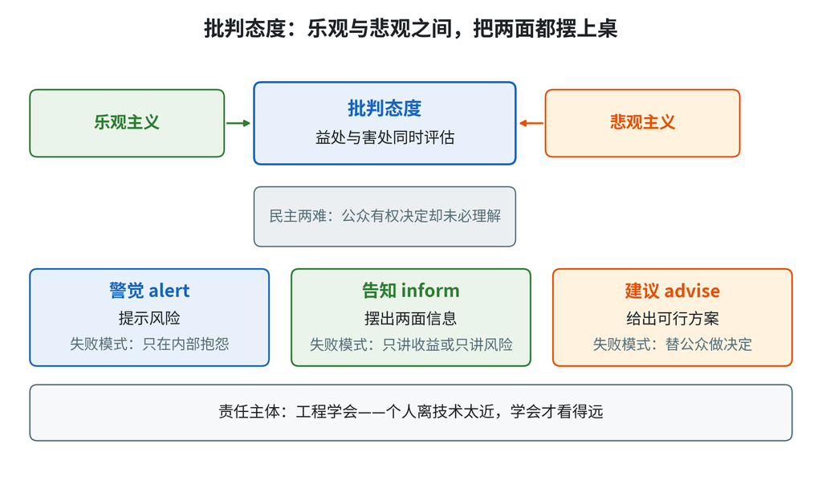

- **是什么**：批判态度＝同时评估益处与害处；乐观**驱动**、悲观**校正**
- **为什么**：公众有权决定科技政策，但简化到失真的信息同样是糊弄
- **怎么判断**：**警觉** → **告知** → **建议**，合成一步＝替公众决定
- 责任主体：**工程学会**而非个人；ASME 参与锅炉规范是正面例子
- 一句话：**批判态度不是反对技术，而是拒绝只看一面**

## 批判态度落地：三个动词的失败模式

- **alert** 的失败是沉默：只在内部抱怨，公众毫不知情
- **inform** 的失败是选择性披露：只讲收益的宣传与只讲风险的恐吓，是同一种失真
- **advise** 的失败是越界：替公众做决定，滑向家长主义
- 现实反差：责任多由**工程学会**承担，但学会常因会员分歧回避公共争论；正面例子是 ASME 参与锅炉规范制定
- 个人可做的三件事：留下书面风险记录、用可核查的数据说话、把判断写成“条件—结论”
- 一句话：**三步不能省，也不能一步包办**

## 技术决定论：技术自主还是社会塑造

[figure not shown]

- 强版本（技术自主）：技术有内在逻辑，社会拦不住；弱版本：技术改变行为、组织与观念，但不否认反作用
- 三条塑造路径：**行为**（减速带逼人减速）、**组织**（流水线把工匠拆成工序）、**观念**（「效率」成为唯一尺度）
- **技术动量**（Hughes）：系统越大、沉没成本越高，越难转向——决定论最有力的证据
- 但动量不是宿命：标准、法规与采购都能改变方向，排放法规就把整条技术路线换掉
- 一句话：**决定论的合理内核是「惯性」，不是「宿命」**

## 技术乐观主义与悲观主义：两种总账

- 乐观主义的三条论证：**总量论**（净收益为正）、**补救论**（技术问题由技术解决）、**选择扩张论**（技术像菜单，选项变多）
- 例证：印度每月新增约 500 万手机用户、班加罗尔酒店客房每晚 299 美元，被当作“技术脱贫”的证据
- 悲观主义的三条反驳：**分配论**（总量增加不等于人人受益）、**锁定论**（选项变多、依赖也变深）、**专家治国论**
- 乐观派自己承认的裂缝（Mesthene）：技术助益民主，却要求越来越多地依赖专家，专家与公众的知识差距不断扩大
- 两种主义都是“整体评价”，而工程决策是“具体评价”：这条产线、这批人、这五年
- 可操作的换算：把“技术好不好”换成“对谁好、好多少、谁承担代价”
- 一句话：**争论不在技术好不好，而在用什么尺度算总账**

## 技术的三重损失：技能、意义与共同体

- **技能**：去技能化（Braverman）——机床被设计成只需非熟练工，技能随人一起走掉
- 技能损失不可逆：老师傅退休，调机手感与异常判断没有写进任何文件
- **意义**：Borgmann 的“装置范式”——手段被隐藏、结果随手可得，过程不再承载意义
- 经典例：壁炉变成集中供暖，家庭添柴、讲故事、交谈的关系链随之消失
- **共同体**：番茄收割机让农场主利润上升，大量农场工人失业，农业社区随之解体
- 三者共同点：都不进财务报表，所以在“效率”论证里权重为零
- 三者共同机制：**受益者与承担者不是同一群人**
- 制造场景：自动化产线把“听声音就能判断轴承”的师傅，变成“按按钮的人”
- 一句话：**能量化的损失被看见，不能量化的损失被忽略**

## 技术与社会相互塑造：社会如何选择技术

- 四种选择机制：**市场**（谁定义“好用”）、**标准法规**、**采购与基础设施**、**价值观争议**
- SCOT 的核心：同一问题常有多个可行解，胜负取决于哪个群体被说服
- 标准机制：排放法规逐级加严，整条技术路线被排除，企业只能跟着换方案
- 采购机制：充电接口、通信频段一旦被公共选择锁定，单个企业只能适配
- 价值观机制：童工曾被算作更“高效”，社会否定童工后，儿童才退出效率计算
- 反向塑造：技术改写社会的“选项集”，减速带、手机、扫码支付改了默认行为
- 共同生产（co-production）：技术秩序与社会秩序一起被造出来，没有先后
- 一句话：**技术给出可能性，社会决定哪一种可能成为常态**

## 技术评估（TA）与预见性治理

- TA 起点：1972 年美国国会设技术评估办公室（OTA），1995 年关闭，欧洲多国议会接手
- 三代 TA：**预警式**（早期警示）→ **建构式**（边研发边评估，把利益相关方拉进设计）→ **实时式**（与研发同步）
- 常用方法：情景分析、德尔菲、交叉影响分析、回溯性案例、共识会议（丹麦式公众参与）
- 负责任创新（RI）四要素：**预见**、**反思**、**包容**、**响应**
- 与第 9 讲风险评估的区别：风险评估问“会不会出事”，TA 问“要不要走这条路”
- 智能制造落点：AI 质检上线前做一次预评估——数据来源、错误代价、替代方案、退出机制
- 失败教训：TA 报告若在决策之后才出，只能进档案柜，不能当刹车
- 一句话：**TA 的价值不在预测得准，而在把后果提前放进议程**

## 技术风险的社会放大

- 概念：风险的社会放大框架（SARF，Kasperson 等，1988）——风险信号经社会环节被放大或衰减
- 放大站与衰减站：媒体、专家、政府、社区、企业、意见领袖，各自筛选与再解释
- 涟漪效应：一次事件波及整个行业、地区甚至同类技术，信任一旦崩塌恢复极慢
- 放大的典型形态：污名化、邻避效应（NIMBY）、连锁的合规审查
- 衰减的典型形态：慢性职业危害被“习惯化”，因为看不见、不突发
- 工程含义：公众感知不是“误解”，而是风险的组成部分；只讲数字的沟通往往失败
- 制造场景：车间“致癌物超标”传闻，即使检测合格，订单与招工照样受影响
- 一句话：**风险＝客观危害×社会解读，两条线都要管**

## 数字技术与劳动：替代、极化与平台

- 三种效应：**替代**（规则化任务被机器接管）、**互补**（任务重组、人机分工）、**极化**（高低技能岗位增、中间层减少）
- 任务偏向型技术进步：被替代的是“任务”而不是“岗位”，岗位被拆开再重组
- 可操作的判断：先列任务清单，标“可规则化／需判断／需手感”，最后才谈岗位
- 平台劳动：算法派单、评分体系、众包计件；劳动关系在“承揽”与“雇佣”之间模糊
- 制造场景：视觉质检替代质检员、AGV 替代搬运、预测性维护新增“数据工程师”
- 技能极化在工厂内部同样发生：会调参的技师涨薪，只做上下料的岗位消失
- 企业与政策的三件事：转岗培训、技能认证、算法规则的透明与申诉
- 一句话：**技术先改任务组合，最后才改岗位名称**

## 数字鸿沟与包容性设计

- 三层鸿沟：**接入**（设备与网络）、**使用**（技能与场景）、**结果**（收益分配），越往后越难弥合
- 工厂里的鸿沟：老工人对触屏 HMI 的适应、听障工人对纯声音报警的依赖、色盲对红绿指示灯的误读
- 包容性设计不是“照顾少数人”，而是让系统在更多条件下都能正常工作
- 通用设计七原则（1997）：公平使用、弹性使用、简单直观、可感知信息、容错、省力、尺寸与空间
- 可感知信息：报警不能只靠一种通道，声音、灯光、文字、振动互为备份
- 无障碍标准：WCAG 的 A／AA／AAA 三级，可作为界面验收的量化依据
- 成本逻辑：越晚改越贵——设计阶段加一个语音提示，比交付后改造便宜得多
- 一句话：**把“极端用户”当测试用例，普通用户也会受益**

## 环境伦理：从合规到可持续

- 准则条款多是**软约束**：NSPE 用“鼓励”（encourage）而非“要求”可持续原则
- 法律是硬约束：NEPA 1969 确立**环评**并设 EPA；1970 清洁空气法、1976 RCRA、1990 污染防治法
- 1990 污染防治法顺序：**源头削减 > 回收 > 处理 > 处置**——“预防原则”的法律化
- 两种立场：**人类中心**（自然只有工具价值）与非人类中心（自然有内在价值）
- 思想资源：Leopold“土地伦理”、Carson《寂静的春天》（1962，DDT）、Hardin“公地悲剧”（1968）
- 环境正义：1980 年代休斯敦 **75%** 焚烧炉与全部填埋场建在非裔社区（人口仅 **25%**）
- 一句话：**环境责任的核心不是“排多少”，而是“谁承担”**

## 环境落点：企业态度、CERES 与 LCA

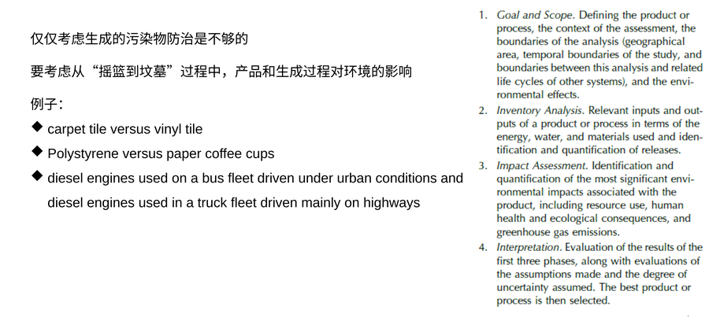

- 企业对环境的三种态度：**低于底线**（宁可交罚款）、**勉强合规**（法规当成本）、**进步型**（主动超越法规）
- CERES 原则（1989 年 Exxon Valdez 后）：保护生物圈、可持续利用资源、减废节能、信息公开、年度审计
- LCA 四步：目标与范围 → 清单分析 → 影响评价 → 解释
- 3M 的 3P 计划：把“污染防治”变成省钱项目
- 一句话：**从末端治理到全生命周期，环境责任才真正进入设计**

## 科技与社会政策：隐私与知识产权

**隐私：我能控制的披露信息**

- 三个维度：信息隐私、财产隐私、选择隐私
- 矛盾：信息化服务需要数据让渡，隐私保护要求限制收集
- 两种立场：实用主义（权衡成本收益）与人本主义（人格与尊严不可交易）
- 立法：美国 Privacy Act 1974；欧盟 GDPR 2018；中国《个人信息保护法》2021

**知识产权：技术成果的归属**

- 缘起：《安妮法案》（Statute of Anne, 1710），第一部现代版权法，确立作者权
- 信息化社会的新问题：软件是否应受保护？如何保护（著作权／专利／商业秘密）？
- 张力：保护过强抑制技术扩散，保护不足没人愿意投入

## 工程国际化：为什么工程要走出去

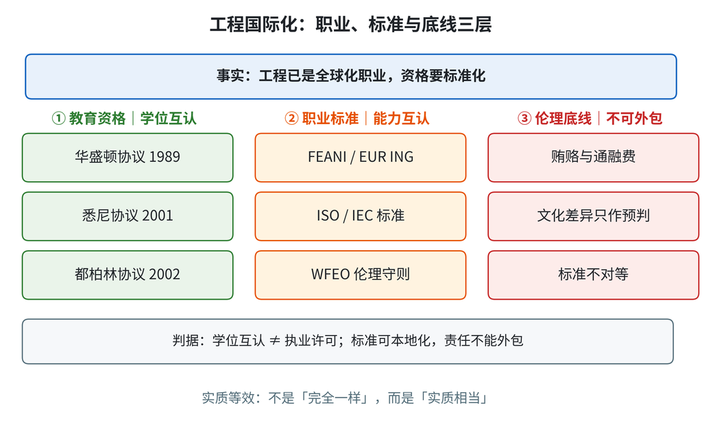

- 四类驱动：**市场**（客户在海外）、**成本**（供应链与人力）、**标准**（认证与互认）、**人才**（跨国团队）
- 中国语境：装备出口、EPC 总包、海外建厂——方案要同时满足母国、东道国与客户三套要求
- 三类新问题：技术标准不对等、文化差异、伦理底线冲突
- 能力清单：外语与本地沟通、目标市场法规、ISO／IEC 标准、合同与合规
- 一条不变的原则：**标准可以本地化，责任不能外包**
- 一句话：国际化把「技术问题」变成「技术＋制度＋文化」的复合问题

## 国际化公司（二）：六类伦理陷阱

| 陷阱 | 典型表现 | 智能制造场景 |
| --- | --- | --- |
| 剥削（经济欠发达） | 利用贫困地区的低工资与低标准 | 把高污染工序转移到环保法规薄弱地区 |
| 行贿（换取特别待遇） | 为获得项目向官员或评标人付款 | 投标时“打点”评标人员 |
| 勒索与通融费 | 为拿到应得服务而额外付费 | 海关、检验环节的“提速费” |
| 裙带关系 | 任人唯亲，岗位安排亲属 | 关键质量岗位安排不合格的亲属 |
| 过度馈赠 | 商务往来变成利益输送 | 供应商以礼品换取验收放行 |
| 家长式作风 | 以“为你好”代替当地参与 | 不做公众沟通直接上项目 |

- 共同特征：单看每一步都“入乡随俗”，连起来却是一条系统性的伦理失守链
- 应对：把“可普遍化的底线”写成公司制度，而不是靠个人临场判断

## 国际工程的六类伦理陷阱（回顾与深化）

| 类型 | 七类的原生形态 | 识别信号 |
| --- | --- | --- |
| 利益输送 | 行贿、勒索与通融费、过度馈赠 | 要求保密；金额与“服务”不匹配 |
| 权力不对等 | 剥削、裙带关系、家长式作风 | 对方没有拒绝的选项 |
| 制度套利 | 协商纳税、双重标准 | 母国不允许、东道国默许 |

- 第七类最易漏：**协商纳税**——税率虚高、默认只报一半；判定看是否违法、是否秘密、能否过黄金法则
- 共同结构：本地合法＋权力不对等＋受益者与受损者分离，单看每一步都“入乡随俗”
- 制度化应对：第三方尽职调查、礼品与招待登记、举报渠道、账簿真实
- 一句话：**陷阱不考验人品，考验制度设计**

## 文化差异与工程实践：Hofstede 六维度

- 来源：Hofstede 于 1960—70 年代调查 IBM 全球员工，最初覆盖 40 个国家与地区，后扩为六维度
- 六维度：**权力距离**、**个人主义／集体主义**、**不确定性规避**、**男性化／女性化**、**长期导向**、**放纵／克制**
- 权力距离高：一线不敢向上报异常，于是必须把“停线权”写进制度，而不是靠自觉
- 不确定性规避高：要更多测试报告与文档，验收清单要提前约定，否则反复返工
- 个人主义／集体主义：绩效奖金发给个人还是班组，直接影响协作方式
- 长期导向：设备维护与培训投入容易被短期产出挤掉，需要制度锁定
- 使用边界：国家均值不能推到个人；把维度当“提问清单”，不当“贴标签”
- 一句话：**维度帮你预判冲突点，不替你下判断**

## 伦理相对主义与绝对主义：论证结构

- 先分清两种相对主义：**描述性**（不同社会的道德确实不同）与**规范性**（对错只相对于文化）
- 从“有差异”推不出“都同样对”：这是事实到价值的跨越，也是最常见的论证漏洞
- 绝对主义的两副面貌：**普遍主义**（底线适用于所有人）与**帝国主义**（把母国做法原样输出）
- 相对主义的两副面貌：**宽容**（尊重差异）与**放任**（标准最低者胜）
- 两个变体：**道德严格主义**（原则逐字执行）与**道德宽松主义**（原则在此不适用）
- 相对主义还会撞上硬约束：母国法律（如 FCPA）、东道国的劳工与安全底线
- 判据：一个做法能否公开、能否普遍化、是否留下申诉渠道
- 一句话：**文化差异解释“做法”，不解释“底线”**

## 跨文化路线：中间道路与三条底线

- 中间道路的定义：不放弃底线，接受次优方案，并主动寻找第三种方案（肥料厂案例）
- 第一步 列冲突项：把标准、做法、期望逐条写出来，标明“必须”与“可谈”
- 第二步 找共同底线：健康与安全、知情同意、不剥削、不贿赂，这几条不进入谈判
- 第三步 设计本地化实现：技术路线、补偿机制、沟通方式都可以本地化
- 第四步 公开辩护测试：这套方案能否在母国公开说明？不能，就还没走通
- 三条底线判据：**可公开**、**可普遍化**、**可救济**
- 常见失败：把中间道路做成“打折的底线”——只降标准，不提替代方案
- 一句话：**底线不谈判，方案可谈判**

## 跨国工程：剥削的五个条件与贿赂的边界

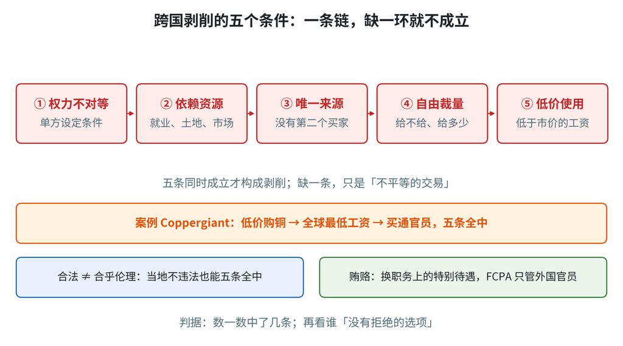

- **是什么**：剥削＝五个条件同时成立——权力不对等 → 依赖资源 → 唯一来源 → 自由裁量 → 低价使用
- **怎么判断**：数五条中了几条；再看谁「没有拒绝的选项」
- **案例**：Coppergiant 低价购铜、全球最低工资、买通官员排挤竞争者——五条全中
- **贿赂边界**：为「职务上的特别待遇」付款；FCPA 1977 只管外国政府官员，勒索性付款有限允许
- **执业边界**：NSPE 96-5——借当地工程师行贿同样违规
- 一句话：**「当地都这样」不是理由**；底线可普遍化，做法可本地化

## 国际标准与规范：ISO、IEC 与 WTO

- 三大标准组织：**ISO**（1947，除电气电子外的国际标准）、**IEC**（1906，电气电子）、**ITU**（1865，电信）
- WTO 的两个相关协定：**TBT**（技术性贸易壁垒，要求以国际标准为基础、非歧视、透明）、**SPS**（卫生与植物卫生措施）
- 管理体系标准：ISO 9001 质量、14001 环境、45001 职业健康安全、26000 社会责任、37001 反贿赂
- 碳与可持续：ISO 14064（温室气体核算）、14067（产品碳足迹）
- 效力来自哪里：合同引用即具约束力，认证即市场准入——这是“软法”的硬约束
- 制造场景：出口设备的电气安全与电磁兼容要按 IEC 体系设计，否则验厂即被否
- 注意：标准是最低共识，不是最高要求；客户规范常常高于标准
- 一句话：**标准是技术语言，也是贸易规则**

## 工程国际标准：三大认证协定

| 协定 | 签署年份 | 对应的工程教育层次 | 核心作用 |
| --- | --- | --- | --- |
| **Washington Accord** | 1989 | 4 年制工程学位（专业工程师） | 工程教育专业认证的实质等效，中国 2016 年成为正式成员 |
| **Sydney Accord** | 2001 | 3 年制工程技术学位（工程技术员） | 工程技术教育层次的互认 |
| **Dublin Accord** | 2002 | 2 年制工程技术文凭（技术员） | 技术员层次的互认 |

- 共同逻辑：**学位互认**——签约方承认彼此的工程教育质量实质等效
- 注意区分：学位互认不等于执业许可；能否执业仍由各国注册工程师制度决定
- 对学生的意义：工程教育认证专业毕业，在签约国申请工程师资格时少一道学历审查

## 华盛顿协议与工程师资格互认

- 华盛顿协议（1989）：**实质等效**（substantial equivalence），不是完全一样
- 认证看产出：12 项毕业能力，从工程知识、问题分析、方案设计到项目管理与终身学习
- 三大协定：华盛顿 4 年制工程师、悉尼 3 年制工程技术、都柏林 2 年制技术员
- 最易混淆：**学位互认不等于执业许可**，PE、CEng、技术士各考各的
- FEANI 走另一条路：不认证学校，直接授予 EUR ING 职称
- 中国 2016 年成为正式成员，认证学位在签约方获实质等效承认
- 学生动作：确认本专业是否通过认证，保留成绩单与课程大纲
- 一句话：**互认承认的是教育质量，不是个人能力**

## 工程职业能力：工程师分类

- 按职能分十类：研究型、开发、设计、产品（生产／制造／工艺）、测试、运行、销售、管理、咨询、教育
- 案例：电动汽车可充电电池的研发与生产
  - 研究工程师做新材料基础试验 → 开发工程师筛选材料 → 咨询工程师提供顾问意见
  - 设计工程师出电池产品模型 → 建筑工程师建厂房 → 生产工程师设计批量生产线
  - 运行工程师维护产线 → 测试工程师测质量指标 → 销售工程师向车厂介绍
  - 管理工程师决定是否扩产、定价、雇人与公司目标
- 结论：同一个产品由十类工程师接力完成，**任何一环的伦理失守都会传导到最终用户**

## 工程教育认证：ABET 的 11 项毕业生能力

| 能力 | 内容 |
| --- | --- |
| a | 应用数学、科学与工程知识的能力 |
| b | 设计并实施实验，以及分析处理数据的能力 |
| c | 设计满足需求的系统、零件或工艺的能力 |
| d | 在多学科团队中工作的能力 |
| e | 识别、表达、解决工程问题的能力 |
| f | **认识职业道德与责任** |
| g | 高效的沟通能力 |
| h | **理解工程方案对全球与社会的影响** |
| i | 认识终身学习的必要性并有能力为之 |
| j | **了解当代社会存在的各种问题** |
| k | 使用工程实践必需的技艺、技能与现代工具 |

- 三条标粗的能力（f、h、j）就是伦理与社会教育的制度化入口

## 注册工程师与职业团体

- **美国注册工程师（PE）五步**：
  - 认可大学的学位 → 通过工程基础考试（FE）→ 四年工程师经验证明 → 推荐信 → 通过原理与实践考试（PE）
- **中国注册工程师制度**：结构工程师、监理工程师、建筑师、安全工程师、环评工程师、质量工程师等
- **职业团体的作用**：交流平台、发表技术论文、召开技术会议、创建技术资料库、讲授课程、提供就业数据
- 例：美国机械工程师协会（ASME，1880）——全球 12.5 万会员、600 余项标准与编码、22 种专业期刊
- 给学生的建议：加入本学科的职业协会，了解行业动态、获取技术信息、认识同行

## 工程技能与优秀工程师的素质

- **四类工程模型**：
  - 数字模型：CAD/CAE（如 UG、SolidWorks、Ansys），效率高、省资源
  - 实物模型：3D 打印与样机，用于方案论证
  - 定量模型：摆钟的线长—周期关系，需简化并评估、修正
  - 定性模型：收益递减的 S 曲线、立方平方法则（变小后体积减小远快于面积）
- **优秀工程师素质**（选摘）：责任感、诚信、工作可靠度、逻辑与量化思维、表达能力、领导力、好奇心、创造力、持续努力、终身学习
- **技术团队**：科学家、工程师、技术专家、技师、技术工人、用户
- 团队核心价值观：褒奖尽职勤奋、尊重队友、早期不批判、接受团队最终方案、公正评判

## 跨国公司的责任：东道国标准怎么取

- 三种取法：**母国标准**（就高）、**东道国标准**（入乡随俗）、**可普遍化底线＋本地化实现**（第三条路）
- 双重标准的检验：同一公司在两国用两套排放与劳保标准，能否在母国公开说明
- 国际软法三件套：OECD 跨国企业准则（1976）、UN 全球契约（2000）、UN 工商企业与人权指导原则（2011）
- 三件套的分工：准则给行为清单，契约给十项原则，指导原则给“保护—尊重—救济”三支柱
- 责任范围：母公司的“尽责管理”覆盖子公司与供应商，合同切不断实际影响力
- 制造场景：海外工厂的劳保用品、加班工时、危废处置、当地用工比例
- 现实约束：东道国执法弱不等于没有责任，母国法院与客户验厂都可能追责
- 一句话：**标准要经得起在母国公开，责任要覆盖到看不见的供应商**

## 贿赂与腐败的边界：FCPA 与反腐败公约

- 定义：为换取与职务职责**不相容的特别对待**而支付的有价值物，核心是“交换协议”
- 与勒索的分界：勒索是付了本该得到的服务；通融费是加速例行程序，可能属轻微勒索，也可能是小贿赂
- 法律地图：FCPA（1977）、OECD 反贿赂公约（1997）、UN 反腐败公约（2003）、英国《反贿赂法》（2010）
- 英国《反贿赂法》的特殊处：设有“商业组织未能预防贿赂”的罪名，合规体系成为抗辩理由
- 为什么禁：腐蚀专业判断、损害行业声誉、破坏市场效率、造成不公平竞争
- 合规四件：第三方尽职调查、礼品与招待登记、账簿与记录真实、举报与调查机制
- 判断三步：是“特别对待”还是“应得服务”？是否需要保密？受损者是谁？
- 一句话：**合法是下限，可公开才是上限**

## 供应链的人权与劳工问题

- 底线文件：ILO 八项核心公约——结社自由、集体谈判、禁止强迫劳动、禁止童工、同工同酬、消除歧视
- 强迫劳动识别：ILO 11 项指标，含扣押证件、扣发工资、债务束缚、限制行动、过度加班
- 工时底线（我国《劳动法》）：每日不超过 8 小时、平均每周不超过 44 小时，加班每月不超过 36 小时
- 硬约束立法：德国《供应链尽职调查法》（2023 年生效）、欧盟《企业可持续尽职调查指令》（2024 年通过）
- 制造场景：海外代工的“宿舍—车间”两点一线、入职押金、护照集中保管
- 审核的局限：验厂可以“演戏”，要看工资流水、离职访谈与申诉记录
- 一句话：**责任边界由影响力决定，不由合同条款决定**

## 冲突矿产与负责任采购

- 范围：**3TG**——锡、钽、钨、金，用于电子元件、电池、硬质合金刀具
- 背景：刚果（金）东部武装团体通过矿产贸易获利，矿产成为冲突的资金来源
- 美国 Dodd-Frank 法案第 1502 条（2010）：上市公司须披露来源并做尽职调查
- OECD 五步框架（2011）：建立管理体系→识别与评估风险→应对风险→第三方审计→报告
- 欧盟《冲突矿产条例》（EU 2017/821）：2021 年 1 月 1 日起对进口商生效
- 行业机制：RMI 的 RMAP 审计、冶炼厂名单、黄金来源核查
- 制造场景：机床刀具的钨、焊料的锡、电镀的金，采购单要能一路追到冶炼厂
- 一句话：**负责任采购不是“不买”，而是“知道从哪来、能证明”**

## 环境标准的国际差异与碳边境

- 事实基础：各国排放标准与执法强度不同，形成“污染天堂”与“碳泄漏”的激励
- 欧盟 CBAM（EU 2023/956）：2023 年 10 月进入过渡期，只报告；2026 年起正式征收
- 覆盖六类：水泥、钢铁、铝、化肥、电力、氢；进口商购买凭证，价格锚定 EU ETS 碳价
- 同步安排：EU ETS 免费配额逐步取消，避免对本土企业形成双重保护
- 争议：是否构成变相贸易壁垒，与 WTO 最惠国待遇、国民待遇原则存在张力
- 发展中国家的主张：共同但有区别的责任，历史排放与人均排放要算进去
- 企业动作：碳核算（ISO 14064／14067）、绿电与工艺替代、供应链碳数据可核查
- 一句话：**环境标准正从“国内法规”变成“贸易门槛”**

## 国际工程案例：海外化肥项目的五道关口

**案例：肥料厂**：某公司在 X 国建化肥厂。产品让当地农民买得起肥料，但排放远超母国标准、符合 X 国法规；治理污染会推高价格，农民可能买不起。

| 关口 | 决策问题 | 失守后果 |
| --- | --- | --- |
| 投标 | 是否承诺母国排放标准 | 中标后无法履约，或偷偷降标 |
| 设计 | 排放限值取哪一国 | 居民健康受损，追责没有依据 |
| 采购 | 环保设备是否“可选” | 省下的钱变成外部成本 |
| 沟通 | 居民是否知情、能否申诉 | 知情同意失效，冲突升级 |
| 验收 | 谁签“达标”、依据是什么 | 证据缺失，责任无人承担 |

- 中间道路：参与运营，同时投入资源寻找更经济的减排方案
- 一句话：**五道关口都留下书面依据，才谈得上负责**

## 全球工程治理与多边机制

- 四层结构，自上而下，约束力递减、覆盖面递增：
  - **多边条约**：UNFCCC 与巴黎协定、ILO 公约、UN 反腐败公约
  - **技术标准**：ISO／IEC／ITU，靠合同引用与认证生效
  - **职业互认**：三大协定与 FEANI、WFEO
  - **企业自律**：OECD 准则、全球契约、行业倡议
- 空缺：没有有执法权的“世界工程组织”，执行落在国内法、合同与客户审核
- 标准之争也是产业之争：谁参与制定，谁就定义“合格”的门槛
- 制造场景：出口设备同时受 IEC 标准、目标国法规、客户验厂与 CBAM 四重约束
- 一句话：**全球治理是多中心的，工程师要做“规则翻译”**

## 工程师的全球责任

- 两种责任：**消极**（不伤害：不行贿、不转移污染、不剥削）与**积极**（促进福祉：培训、技术转移、能力建设）
- 角色论证：职业是一种社会角色，角色道德跨文化可理解（如父母与子女），所以专业主义可以国际化
- 能力路径（Nussbaum 十项）：工程直接影响健康、营养、住所、教育与社会参与
- 个人与组织：个人扛不下全部，但“知情而不行动”本身也是一种选择
- 可操作三条：把底线写进合同条款、建立本地申诉渠道、留下可核查的记录
- 边界感：既不做“救世主”，也不做“只是执行命令的人”
- 一句话：**全球责任就是不把成本转嫁给看不见的人**

## 技术交流中的诚实：数据与图表的呈现

| 类型 | 表现 | 识别方法 |
| --- | --- | --- |
| **选择性报告** | 只报有利数据，隐藏重复试验与失败工况 | 要求给出全部试验记录与样本量 |
| **坐标轴截断** | 纵轴不从 0 起、对数轴未标注，把微小差异画成陡变 | 检查轴起点、刻度与单位 |
| **显著性误用** | 把 p 值当重要性，多重比较不校正，不显著说成趋势 | 看效应量与置信区间，不只看 p 值 |
| **样本代表性不足** | 样本量小、只测合格批，却外推到全产品 | 追问抽样方案与工况覆盖 |

- 写作规范：摘要背景 10%／方法 70%／结论 20%；多定量少定性，**禁止无依据的主观推断**
- 图表规范：标物理量、单位、样本量、误差棒；**AI 生成内容须标注**工具与用途并人工复核
- 案例：STAP 细胞论文篡改捏造（2014 年撤稿）、黄禹锡干细胞成果伪造（2005 年判刑）

> 技术交流的诚实 = **数据可追溯 + 结论可复核**

## 技术交流中的倾听与风险沟通

- **倾听的三个动作**：复述确认（“我理解你的意思是……”）、追问依据、记录分歧；学术报告的收尾是认真倾听提问并解答
- **风险沟通的目标不是说服，而是知情选择**：让受影响者理解风险并自主决定
- 四要素：
  - 受众分层：同行、管理层、公众、监管者，用各自能理解的语言
  - 信息内容：发生概率 × 后果、不确定性范围、可采取的防护措施
  - 渠道与时点：越早越好；坏消息第一时间上报，不等“调查清楚”
  - 双向机制：给受影响者表达、质疑与申诉的渠道
- 反例：Biotrial 药物试验（2016 年法国雷恩，1 死 5 伤）——非临床评估人曾警告动物实验出现神经病变，监管方无视警告仍称“患者安全能够得到保证”
- 一句话：**倾听是把技术判断翻译成受影响者能理解并选择的信息**

## 本部分小结：四条主线与三个工具

- 主线一 技术是社会产物：系统论定义、双向因果、社会选择技术路线
- 主线二 评价要有批判态度：乐观驱动、悲观校正，警觉—告知—建议三步
- 主线三 国际化是制度问题：三大协定与 ISO 标准给语言，六类陷阱给警戒线
- 主线四 责任要可操作：中间道路＋三条底线判据（可公开、可普遍化、可救济）
- 工具一 **双向因果图**（谁塑造谁）：用来分析
- 工具二 **陷阱识别表**（类型—信号—应对）：用来判断
- 工具三 **中间道路四步**（列冲突—定底线—本地化—公开测试）：用来给方案
- 一个提醒：所有结论都要能落到“谁受影响、受多大、凭什么”
- 一句话：**技术可评价、标准可互认、底线不可让**

## 本部分复习与练习

| 题型 | 考点 | 答题要点 |
| --- | --- | --- |
| 概念辨析 | 技术决定论、乐观主义、悲观主义 | 先给定义，再给一个反例 |
| 案例判断 | 六类陷阱的归类 | 指出类型、信号与受损者 |
| 论述 | 中间道路的可行性 | 底线、方案、公开辩护三段 |

- 练习一：用双向因果解释“某厂上马黑灯车间”对当地用工的影响，正反各举一条证据
- 练习二：给出一个“通融费”情境，判断它属于勒索、通融费还是小贿赂，并说明依据
- 练习三：为某出口项目列一张合规清单，至少覆盖标准、劳工、环境、反腐败四类
- 自测：不看讲义说出三条底线判据，并各配一个本讲案例
- 一句话：**能举例、能定位、能辩护，才算学会**

## 本部分案例讨论：配方奶粉该不该撤柜

**情境：配方奶粉**：某公司是 X 国唯一的婴儿配方奶粉销售商。许多母亲用受污染的水冲调、为省钱过度稀释，导致婴儿营养不良。工程师 John 建议停售，管理层同意，产品撤出 X 国。

- 讨论一：撤柜是“保护”还是“剥夺选择”？两种回答各需要什么证据？
- 讨论二：本案属于**弱家长主义**还是**强家长主义**？判据是母亲们是否“知情且有能力选择”
- 讨论三：除撤柜还有哪些方案——改包装与冲调说明、配净水设备、降价补贴、社区培训？各自代价是什么
- 讨论四：若不停售，公司对营养不良的婴儿是否负有责任？依据是因果，还是可预见性
- 讨论要求：每组给出“方案—受益者—受损者—最坏情况—补救”五行表，再用三条底线判据自检
- 一句话：**家长主义的正当性，取决于被越过的那个人是否真的无法判断**

## 推导留给 AI：技术的社会意义与工程国际化（汇总）

**推导留给 AI**（先自己推，再让 AI 校验，最后交完整推导）

- ① 查证 Washington Accord 的成员与生效年份，说明“学位互认”与“执业许可”的区别；中国加入后对工程教育认证提出了哪些具体要求？
- ② 用“技术内嵌于社会”的框架分析新能源汽车路线：是技术选出社会，还是社会价值观选出技术？
- ③ 肥料厂案例：分别站在相对主义、绝对主义、中间立场写出三段论证，并指出每种立场的漏洞。
- ④ 六类国际化伦理陷阱中，哪一类在智能制造项目里最隐蔽？给出一个具体工程场景与识别信号。
- ⑤ FEIAP、JSPE、CEC、WFEO 四份职业守则的共同底线是什么？与 NSPE 准则相比多了哪些内容？

# 第二部分 · AI 伦理与智能制造责任

- 人工智能伦理风险的三个维度：算法、数据、应用
- 算法安全、可解释性与决策困境；数据隐私与个人敏感信息
- 算法歧视与算法滥用的具体案例：COMPAS 卢米斯案、亚马逊招聘、荷兰 SyRI 福利评分
- 治理框架：两条原则、八项评估指标、五步风险管理流程；自动化安全底线与人机协作责任

## AI 伦理为何成为工程伦理的核心议题

- 工程伦理的传统对象是**事故与物**：桥梁、锅炉、安全联锁
- AI 把对象换成**判断与分配**：谁被录用、谁被放行、谁被监控
- 工程即社会实验：有实验对象、结果不确定、实验者须承担责任
- AI 让这场实验在三处放大：
  - **规模**：一套模型同时服务所有工厂与客户
  - **速度**：毫秒级决策，人来不及复核
  - **粘性**：模型固化历史，预测又反过来生成新数据
- 权力不对称：被决策者常不知情、无申诉渠道
- 责任鸿沟：自主性越强，侵权与产品责任越难适用
- 结论：伦理不是附加审查，而是**设计输入**

## AI 伦理的三维度：算法、数据、应用

- **算法维度**：算法安全、可解释性、决策困境
- **数据维度**：隐私保护、个人敏感信息处理
- **应用维度**：算法歧视与算法滥用
- 三者之上是长期和间接的风险：就业、产权、竞争、责任
- 与传统自动化的区别：依据统计学规律、过程难解释、决策可复制

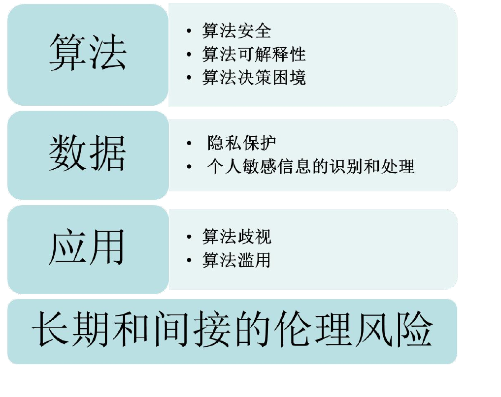

## AI 系统的伦理风险分类

- 三横：**算法**（安全、可解释、决策困境）、**数据**（隐私、敏感信息）、**应用**（歧视、滥用）
- 第四类：长期与间接风险——就业、产权、竞争、责任
- 分类的目的是**对上治理工具**：算法→可验证、可解释、可中断；数据→最小必要、去标识；应用→限定用途、人类主体性
- 一句话：**先定位风险落在哪一类，再谈用什么工具**

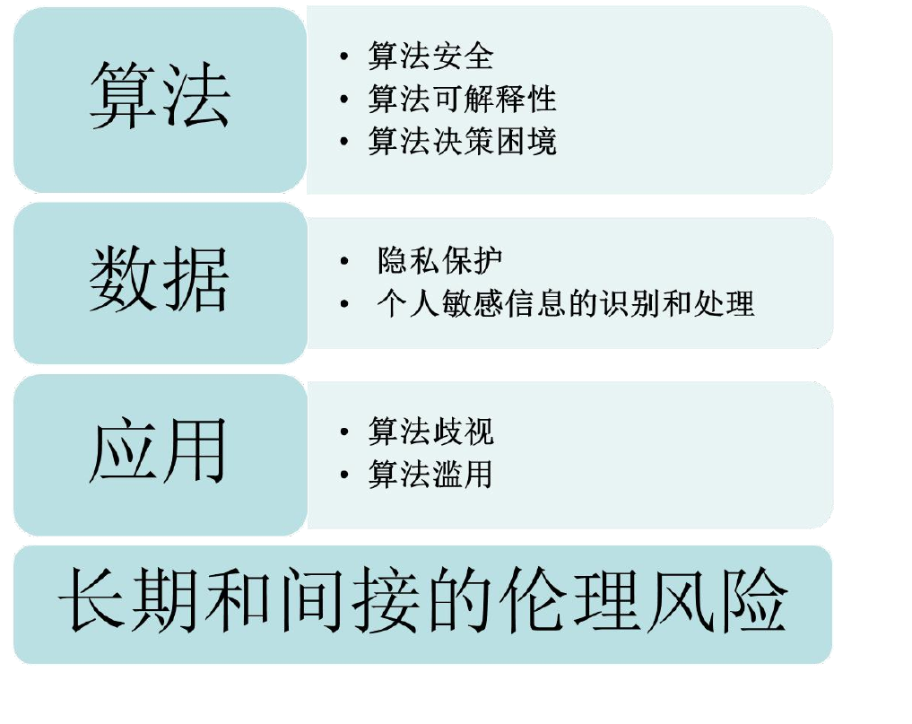

## 算法偏见的来源：数据、模型与部署

- **数据层**：历史偏见、选择偏差、标签偏差、代理变量
  - 历史录用记录偏向男性，模型便学到“男性更合适”
  - 邮编、社团、措辞都能替代性别，删字段不等于去偏见
- **模型层**：目标函数只奖励预测精度，不奖励公平
  - 特征交互与正则化会放大少数群体的误差
  - 反馈回路：预测影响决策，决策又生成新数据
- **部署层**：换场景、换人群、调阈值，都会改变公平性
- 实验室达标不等于上线公平，须分群体、分场景评估
- 治理对应：数据审计、公平约束、上线前影响评估

## 算法偏见案例：招聘、信贷与司法

- 三个场景的共同结构：**历史数据 → 模型学习 → 资源分配**
- 招聘：亚马逊用十年简历训练筛选模型，女性简历被降权，2017 年团队解散
- 信贷：报告列举三类表现——压低弱势群体得分、拒绝有色人种贷款、向低收入群体推送高息贷款
- 司法：COMPAS 用于美国 50% 以上州的保释与量刑；卢米斯被判 6 年，2017 年 6 月联邦最高法院拒绝受理
- ProPublica：黑人被错误评估为高风险的几率约为白人的两倍

| 场景 | 被分配的资源 | 偏见机制 |
| --- | --- | --- |
| 招聘 | 面试与录用机会 | 简历以男性为主，女性被降权 |
| 信贷 | 贷款资格与利率 | 弱势群体得分被压低 |
| 司法 | 保释、量刑与假释 | 历史执法数据偏斜，假阳性率高 |

- 共同教训：**总体准确率达标，不能证明分群体公平**

## 算法歧视（二）：COMPAS 与卢米斯案

- 背景：COMPAS 等风险评估软件用于美国刑事诉讼，预测再犯率、出庭可能性，辅助保释、量刑与假释；美国 50% 以上的州有法官使用
- 案件：2013 年威斯康星州诉卢米斯案
  - 被告因驾驶未获车主同意的车辆（该车已报失窃）并逃避警察而被捕，COMPAS 判其“高风险”，最终被判有罪并服刑 6 年
  - 被告上诉：危险等级认定可能考虑了性别与种族，构成歧视
  - 威斯康星州最高法院维持原判；2017 年 6 月联邦最高法院拒绝受理
- 证据：非营利组织 ProPublica 研究显示，黑人被错误评估为高犯罪风险的几率两倍于白人
- 教训：群体层面的错误率差异，即使总体准确率达标，也可能构成歧视

## 算法滥用：四种场景与三条边界

- 四种典型场景：
  - **娱乐媒体**：推荐算法导致沉迷、内容同质化、价值观扭曲
  - **电子商务**：“大数据杀熟”式差别定价
  - **教育**：课堂摄像头分析学生表情计算专注度，儿童信息泄露与误判风险
  - **安防定罪**：用算法预测“潜在犯罪人”，违背无罪推定原则
- 三条治理边界：
  - **限定用途**：为某目的收集的数据不得未经同意挪作他用
  - **坚持人类主体性**：人的经验判断与算法的数据优势结合，不过度依赖
  - **标准引导**：用行业标准与国家技术标准把伦理取向写进算法目标
- 判断口诀：目的正当、方式适度、范围不越界

## 隐私与数据保护：从同意到最小必要

- 制度基线：《个人信息保护法》2021 年 11 月 1 日施行，八章七十四条
- **最小必要**（第 6 条）：目的明确合理、与目的直接相关、影响最小、范围最小
- 合法性基础（第 13 条）：同意、合同必需、法定义务、公共利益等
- 敏感个人信息（第 28 条）：生物识别、医疗健康、金融账户、行踪轨迹、不满十四周岁未成年人信息等
- 处理敏感信息须**单独同意**（第 29 条），并告知必要性与影响（第 30 条）
- 制造现场三问：人脸门禁是否必需？工位摄像头拍什么？可穿戴数据存多久？
- 判断：**同意不等于正当**，仍要过必要性审查
- 违规后果：责令改正、警告、罚款，直至停业整顿与吊销执照

## 数据治理：采集、存储、使用与销毁

- 数据治理不是一次合规检查，而是**全生命周期**的制度
- 四条原则：目的限定、最小必要、分级分类、全程留痕
- 分级分类是前提：不知道数据属于哪一级，就谈不上保护
- 制造企业最容易失守的两处：**采集端无告知**、**销毁端无记录**

| 环节 | 关键动作 | 制造场景 |
| --- | --- | --- |
| 采集 | 告知同意、最小必要、来源审查 | 人脸门禁、工位摄像、设备联网 |
| 存储 | 加密、分级、最短期限、出境合规 | 工艺参数、考勤、客户图纸 |
| 使用 | 目的限定、去标识、权限审计 | 训练质检模型、绩效分析 |
| 销毁 | 到期删除、介质销毁、留痕 | 离职数据、过期订单 |

- 一句话：**能说清“从哪来、给谁用、何时删”，才算治理到位**

## 透明性与可解释性：从黑箱到 xAI

- 可解释性：解释**输入的哪些特性**导致了某个特定输出
- 黑箱的根源：多层非线性、变量关系纠缠、涌现性与自主性
- 三类解释路径：
  - 按内容：过程解释（怎么算）与决策解释（为何是这个结果）
  - 按路径：模型中心（全局逻辑）与主体中心（个案）
  - 反设事实：不打开黑箱，只解释“改什么，结果就变”
- 为什么是伦理问题：关涉知情利益与人的主体地位
- 制度要求：ACM 七准则列“解释”、GDPR 第 71 条确立解释权、IEEE 伦理准则要求可解释
- 工程做法：特征归因、反设事实、样例对照、模型卡

## 可解释性与性能的权衡

- 张力来源：精度最高的模型往往最难解释，解释越细成本越高
- 报告提醒：**过度公开透明或强化可解释性，不利于创新与社会福利**
- 折中一：解释**相关关系**而非因果关系，降低企业解释成本
- 折中二：按风险分级选择模型与解释强度
- 折中三：事后解释、人工复核、申诉渠道组合使用

| 场景风险 | 模型与解释策略 | 复核要求 |
| --- | --- | --- |
| 低（内部辅助） | 高精度模型，事后解释 | 抽检 |
| 中（工艺调整） | 可解释模型或混合方案 | 逐批确认 |
| 高（人身、准入） | 白盒优先，规则可读 | 人工实质复核 |

- 一句话：**可验证是底线——同输入应得同输出**

## 问责：谁为算法负责

- 三种责任：角色责任（在位当为）、过失责任（可归咎）、前瞻责任（防患未然）
- AI 的特殊困难：**责任鸿沟**——自主性越强，因果链越难还原
- 组织稀释机制：责任线故意模糊、细节下推、功劳上收、不留文字
- 群体归责原则：责任程度取决于**本可合理期待其阻止**的程度
- 可问责四要件：主体可识别、因果可查明、规范可适用、后果可施加
- AI 证据链：数据来源、模型版本、阈值设定、复核记录、变更审批
- 一句话：**问责不是找替罪羊，而是让每个环节留下可查的痕迹**

## 自动化决策的边界：人在回路

- 四种运行方式：人工决策、人在回路中、人在回路上、人在回路外
- 边界判据三问：后果可逆吗？受影响者能否申诉？依据能否说明？
- 法律边界：《个人信息保护法》第 24 条——重大影响决定，个人可要求说明，并可拒绝**仅由**自动化决策作出
- 高风险场景：解雇与绩效、信贷与准入、医疗与安全联锁
- 有效复核的三个条件：有权限、有时间、有信息
- 反例：**橡皮图章式复核**——只点确认，不看不问不改
- 设计要点：把不确定性、置信度与依据一并呈现给复核者

## 自动化安全底线与人机协作责任

- **三条安全底线**：
  - 异常输入仍可用：模型遇到分布外输入必须降级并报警，不能静默输出
  - 人类干预始终有效：急停、切断开关、权限回收（安全可中断性）
  - 决策可追溯：留存模型版本、输入、输出与人工复核记录
- **人机协作的责任划分**（自动化等级 → 责任重心）：

| 运行方式 | 人的角色 | 责任重心 |
| --- | --- | --- |
| 人工决策 | 全部判断 | 人 |
| 人在回路中 | 逐次确认 | 人为主，系统为辅 |
| 人在回路上 | 异常时接管 | 系统为主，人的监督责任 |
| 人在回路外 | 只设边界 | 设计者与组织 |

- 一句话：**责任不能随自动化等级转移给算法**

## 安全与鲁棒性：对抗样本与分布漂移

- 对抗样本：对输入做**人眼几乎不可见**的扰动，使分类结果翻转
- 物理世界同样成立：贴纸、反光、遮挡、光照变化都能欺骗视觉模型
- 分布漂移：换批次、换供应商、换季节、镜头污染、工艺参数调整
- 三类监测指标：输入分布、置信度分布、人工抽检一致率
- 工程措施：OOD 检测与拒识、降级报警、灰度上线、回归测试集
- 组织措施：红队测试、变更评审、上线后持续监控
- 报告案例：无人车识别不出袋鼠——跳跃姿态不在训练分布内
- 底线：**宁可拒识报警，不可静默输出**

## 人机协作的伦理：信任、依赖与责任

- 信任的两个来源：**可预测**（行为稳定）与**可验证**（结果可查）
- 过度信任的代价：自动化偏见，人倾向于接受机器给的第一个答案
- 长期代价：技能退化，人失去独立判断的能力
- 信任不足的代价：弃用、绕过、私自改参数，风险反而更高
- 责任分工：机器给建议，人做决定，组织定规则
- 设计：暴露不确定性、关键动作要求确认、保留人工接管
- 组织：训练与复训、异常演练、复核质量抽查
- 一句话：**好的协作是让人保持“能接管”的状态**

## 智能制造中的 AI：三类应用与风险

- 共同点：都用历史数据预测未来，再把预测变成现场动作
- 风险不只在模型：**数据从哪来、动作谁执行、出错谁复核**同样关键
- 共同失效模式：训练分布与现场分布不一致，且没人负责发现
- 排产的公平问题最容易被忽略：权重一改，交期分配就变
- 三条控制线：模型指标、现场规程、责任条款

| 应用 | 主要风险 | 控制点 |
| --- | --- | --- |
| 视觉质检 | 漏检流出、误检拖累节拍、换型失效 | 分缺陷类型的召回率、阈值审批 |
| 预测维护 | 误报停机、漏报断机、数据权属争议 | 剩余寿命置信区间、备件联动 |
| 智能排产 | 目标权重不透明、交期与公平冲突 | 目标函数公开、人工调整留痕 |

- 一句话：**AI 的风险，一半在算法，一半在接口**

## 国家伦理框架：两条原则与八项指标

- **两条基本原则**：
  - **人类根本利益原则**：AI for good；保障人的尊严与基本权利；算法透明、避免歧视；效益公平分配、缩小数字鸿沟；隐私保护、防止数据滥用
  - **责任原则**：开发端——透明度原则（可解释性、可验证性、可预测性）；应用端——权责一致原则（留存算法、数据、决策记录；即使无法解释结果，使用 AI 决策的机构仍要负责）
- **八项评估指标**：
  - 算法：透明度、可靠性、可解释性、可验证性
  - 数据：敏感信息处理的审慎性、隐私保护的充分性
  - 社会影响：向善性、无偏性

## AI 伦理治理：欧盟法案与中国办法

- 欧盟《人工智能法案》2024 年 8 月 1 日生效，按**四档风险**分级
- 高风险义务：风险管理、数据治理、技术文档、记录、透明度、人类监督
- 罚则上限 3500 万欧元或全球营业额 7%；高风险义务已分档推迟，最晚至 2028 年 8 月
- 中国路径：**分类分级加场景监管**，不以一部统合法定全貌
- 生成式 AI 暂行办法 2023 年 8 月 15 日施行：训练数据合法、内容标识、安全评估与备案

| 框架 | 核心思路 | 对制造企业的要求 |
| --- | --- | --- |
| 欧盟 AI 法案 | 风险分级、合规前置 | 出口设备先判等级、留技术文档 |
| 中国生成式 AI 办法 | 分类分级、内容与数据并管 | 管住输入、标识输出 |
| ISO/IEC 42001 | 管理体系、持续改进 | 并入质量与环境体系 |

## 算法影响评估：把风险写成文件

[figure not shown]

## 案例：荷兰算法治理的两记警钟

- **SyRI 风险评分系统**：荷兰政府用于识别福利欺诈，把住房、税务、补贴等多部门数据汇入风险模型，圈定“高风险”个人与社区
- 2020 年 2 月，海牙法院裁定 SyRI 违反《欧洲人权公约》第八条（私生活受尊重权）：**算法不透明**，个人无法知晓自己被如何评分
- **托儿补贴丑闻**：税务部门用风险画像筛查补贴申请，约 **2.6 万**个家庭被错误指控欺诈、要求退还巨额补贴
- 受影响家庭中**移民背景比例畸高**；2021 年 1 月 15 日，荷兰内阁为此集体辞职
- 共同教训：
  - 第一道防线是**透明度与可解释性**
  - 第二道是**申诉与救济**：被算法判定的人必须能问“为什么是我”
  - 第三道是**人工复核**：高风险结论不能由模型单独作出
- 一句话：**当算法决定人的命运，问责必须比算法更快到位**

## 伦理审查与伦理委员会

- 制度依据：《科技伦理审查办法（试行）》2023 年 12 月 1 日施行
- 适用范围：涉及人或动物的研究，以及人工智能等伦理敏感领域
- 委员会构成：研发负责人、法务合规负责人、伦理协调专员，可聘外部专家
- 审查要点：目的正当、比例适当、知情同意、风险收益、退出与救济
- 审查不是一次盖章：上线后的重大变更仍要复审
- 与机构审查委员会（IRB）的差别：对象从“受试者”扩展到**数据与算法**

| 角色 | 职责 |
| --- | --- |
| 伦理委员会 | 审批高风险项目、裁定争议、组织复审 |
| 业务伦理小组 | 日常识别、汇总问题、执行整改 |
| 监督部门 | 抽查执行、受理举报、独立报告 |

## 案例：AI 质检漏检的责任归属

情景（课堂设定）：视觉质检替代人工全检，一批次漏检流出，客户索赔。

- 事实链：新批次反光 → 图像漂移 → 调高阈值降误检 → 取消人工抽检 → 未留模型版本
- 阈值是经济与伦理参数：$C = c_{\mathrm{FN}}N_{\mathrm{FN}} + c_{\mathrm{FP}}N_{\mathrm{FP}}$
- 漏检流出成本远高于复检成本时，阈值应偏向保守
- 责任按**控制力**与**注意义务**分配，不随自动化转移

| 主体 | 应尽义务 | 失职点 |
| --- | --- | --- |
| 算法供应商 | 说明适用边界、漂移监测 | 未提示换型风险 |
| 工艺部门 | 变更评审、参数验证 | 未做新批次验证 |
| 质量部门 | 放行判据、抽检方案 | 取消抽检未评估 |
| 管理层 | 资源与制度 | 以节拍压质量 |

- 一句话：**合同里的验收标准与数据责任，比事后追责有效**

## 案例：预测性维护的数据权属

情景：设备商提供预测维护服务，持续采集振动、温度、工艺参数与操作记录。

- 争议三方：使用者（数据产生）、设备商（模型与算法）、平台（存储与算力）
- 法律现状：我国未设统一的“数据所有权”，靠**分类分级、合同与技术措施**
- 三类数据分开谈：原始运行数据、衍生特征、模型参数
- 竞争风险：用甲厂数据训练的模型服务乙厂，可能泄露工艺诀窍
- 条款设计：目的、范围、期限、脱敏、审计、退出与删除

| 数据类型 | 主要主张者 | 风险 | 条款要点 |
| --- | --- | --- | --- |
| 原始运行数据 | 使用者 | 工艺参数外泄 | 目的限定、脱敏 |
| 衍生特征 | 设备商 | 归属不清 | 明确衍生数据权属 |
| 模型参数 | 设备商 | 反向推断 | 不得输出可还原信息 |

## 案例：生成式 AI 与知识产权

- 三条链分开看：**训练数据**（输入）、**模型权重**（本体）、**生成物**（输出）
- 训练数据：生成式 AI 办法第 7 条要求来源合法、不得侵害知识产权
- 模型权重：多按商业秘密保护；相关方法可申请专利，但要以公开换保护
- 生成物：人类智力投入程度影响可版权性；2023 年 11 月北京互联网法院首例 AI 生成图片案认定其构成美术作品
- 企业风险：员工把客户图纸贴进公网模型，既泄密又难追回
- 标识义务：生成合成内容标识办法 2025 年 9 月 1 日施行，分显式与隐式标识
- 操作建议：准入清单、脱敏输入、输出审核、全程留痕

## 工程师的 AI 伦理能力：识别、评估与处置

- **识别**：画利益相关方图，列最坏情形，标注不可逆后果
- **评估**：可能性乘以后果，分群体看指标，追问“依据能否说明”
- **处置**：改设计、限用途、加复核、上报、拒绝、披露
- 处置有优先级：先改设计，再改流程，最后才是拒绝与举报
- 对应 Harris 的三项责任：**提醒、告知、建议**
- 个人底线：不隐瞒指标、不伪造验证记录、不绕过复核

| 能力 | 具体动作 | 产出物 |
| --- | --- | --- |
| 识别 | 风险清单、利益相关方分析 | 风险登记表 |
| 评估 | 分群体指标、影响评估 | 评估报告 |
| 处置 | 设计变更、上报、拒绝 | 决策记录 |

## 负责任创新的框架：预期、反思、包容、响应

- RI 把伦理从“事后问责”移到“过程之中”，强调四个维度
- 四维度不是流程四步，而是四个必须回答的问题
- 与合规的区别：合规是下限，RI 要求**能改、能停、能补偿**
- 反例：把 RI 做成一张勾选表，勾完就归档
- 中国政策呼应：《关于加强科技伦理治理的意见》五原则——伦理先行、依法依规、敏捷治理、立足国情、开放合作
- 落地做法：设计评审加四问，评审记录进项目档案

| 维度 | 核心问题 | 制造企业动作 |
| --- | --- | --- |
| 预期 | 三年后会怎样 | 情景演练、失效推演 |
| 反思 | 我们忽略了谁 | 评审加伦理项 |
| 包容 | 谁还没被咨询 | 工人代表、用户访谈 |
| 响应 | 出错怎么退 | 回退方案、补偿机制 |

## 本部分小结：从风险到制度

- 一条主线：风险分类 → 偏见、隐私、解释、问责 → 治理工具 → 案例 → 能力
- 三句话：
  - 准确率不等于正当，**分群体指标**才是公平的入口
  - 责任不随自动化转移，**控制力**决定责任重心
  - 解释与记录是最便宜的风控，**留痕**是最硬的证据
- 与第 8、9 讲衔接：准则 → 风险 → 组织 → AI，伦理主线在此收口

| 层次 | 核心问题 | 工具 |
| --- | --- | --- |
| 技术 | 模型错在哪 | 分群体评估、OOD 检测 |
| 组织 | 谁决定、谁复核 | AIA、伦理委员会 |
| 制度 | 依据什么、怎么办 | 法律、标准、合同 |

## 推导留给 AI：AI 伦理与治理（汇总）

**推导留给 AI**（先自己推，再让 AI 校验，最后交完整推导）

- ① 用“算法安全—可解释性—决策困境”三条线解释：为什么模型的错误率已经达标，仍可能构成伦理风险？
- ② 数据驱动歧视的四种形态分别对应哪些数据治理动作？对制造现场的员工数据采集给出三条可执行规则。
- ③ COMPAS 案中，如果模型确实比法官更准确，能否使用？请分别用后果论与义务论给出论证。
- ④ 查证 GB/T 35273 与《个人信息保护法》对“个人敏感信息”的界定差异，并说明对车间人脸门禁的合规要求。
- ⑤ 把“安全可中断性”翻译成工业机器人的具体装置与操作规程，指出车间里最容易被忽略的一条。

## AI 伦理复习与练习

- 概念：区分数据偏见、模型偏见与部署偏见，各举一例
- 计算：月产 10 万件，漏检流出成本 800 元/件，误检复检成本 20 元/件；设漏检率 0.2%、误检率 1.5%，求期望质量成本，并说明阈值该往哪调
- 案例：用质检漏检的事实链，写出四个主体的责任分配与一条合同条款
- 制度：写出算法影响评估的五个步骤与三个触发条件
- 论述：比较欧盟风险分级与中国分类分级，说明各自对制造企业的影响
- 辩论：模型比人更准时，能否用于解雇决策？用后果论与义务论各写一段
- 自测：用一句话解释“责任鸿沟”与“人在回路”

# 第三部分 · 智能设计应用

- 机器视觉检测：系统组成、相机与镜头选型、光源与图像采集、缺陷检测与尺寸测量流程
- 三个落地案例：羊只姿态检测（YOLOv5）、图神经网络预测裂纹（GAT）、振源智能识别（盲源分离）
- 看懂算法图：YOLOv5 的 FPN、GNN 的注意力结构、抛丸器的振动频谱
- 算法落地的工程约束：数据、实时性、可解释、维护与责任

## 智能设计的总体框架

- **智能设计**：把设计、检测、运维中的判断变成可计算、可验证的模型
- 四个层次：对象（产品／工艺／产线）→ 数据（图像／振动／图）→ 模型（CV／GNN／大模型）→ 决策（放行／报警／排程）
- 两类任务：**判别**（有无缺陷、哪个振源）与**生成／优化**（方案、参数、顺序）
- 一条主线：物理信号 → 数据表示 → 模型 → 工程判据 → 现场动作

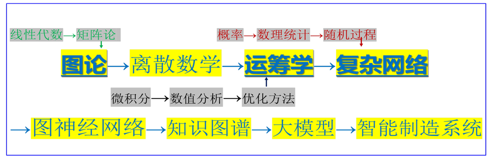

## 视觉四步：像素矩阵→卷积→形态→边缘

> 上一页把质检判定链走通；这一页回到源头——相机给的是像素矩阵，缺陷是怎么被“算”出来的。
- **成像**：一张灰度图就是像素矩阵，取值 0–255；彩色是三通道矩阵，深度图是距离矩阵
- **降噪**：3×3 卷积核滑动加权求和；高斯核平滑噪声又保留特征，中值滤波专治椒盐噪声
- **形态学**：腐蚀去小亮点、膨胀填小孔、开运算断细颈、闭运算连缺口；击中-击不中用于模板匹配
- **边缘**：灰度突变处就是边缘，用梯度差分找；Sobel 抑制噪声，Canny 低错误率、定位准、去孤立点
- **分割与识别**：区域生长提裂纹、霍夫变换连直线、CNN 提特征做分类——算法组合本身就是创新

**结论：视觉质检＝在矩阵上做四步变换，缺陷从“看得见”变成“算得出”。**

## 运行例子：6×6 图像上的 Sobel

> 上一页说“边缘＝灰度突变”；这一页用 6×6 的小矩阵把 Sobel 真跑一遍。

```python
import numpy as np
from scipy.signal import convolve2d

img = np.array([[10,10,10,10,10,10],[10,10,10,10,10,10],
                [10,10,80,80,10,10],[10,10,80,80,10,10],
                [10,10,10,10,10,10],[10,10,10,10,10,10]], float)
kx = np.array([[-1,0,1], [-2,0,2], [-1,0,1]])   # Sobel 横向核
print("Gx:", convolve2d(img, kx, mode="valid").astype(int).tolist())
print("Gy:", convolve2d(img, kx.T, mode="valid").astype(int).tolist())
```

```
Gx: [[-70, -70, 70, 70], [-210, -210, 210, 210], [-210, -210, 210, 210], [-70, -70, 70, 70]]
Gy: [[-70, -210, -210, -70], [-70, -210, -210, -70], [70, 210, 210, 70], [70, 210, 210, 70]]
```

**结论：卷积核一扫，矩形的四条边在矩阵上原形毕露——所谓“视觉”，就是在矩阵上做差分。**

## 图：Sobel 的输出长什么样

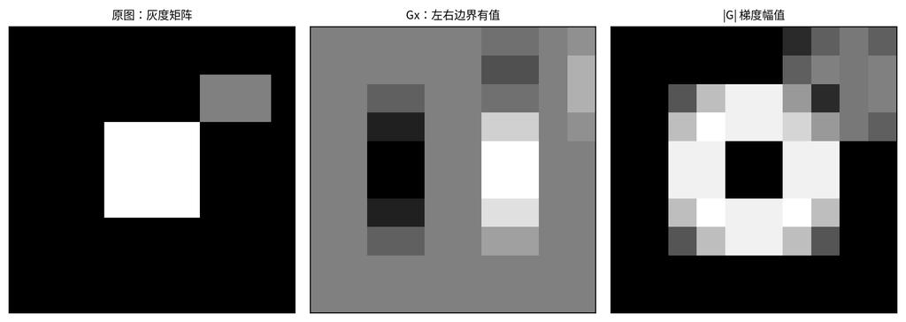

- 左：原图，一块 4×4 亮块加一处 2×3 小瑕疵；中：$G_x$ 只在**左右边界**有值，块内部与背景全 0
- 右：幅值图把两个方向合起来，缺陷的**轮廓**完整浮出来——这就是后面形态学与 CNN 的输入
- 真实质检里再加阈值与连通域：轮廓围出的面积、长短轴，就是判定缺陷类型的特征

**结论：从灰度矩阵到轮廓图只差两个卷积核——中间每一步都能画出来、也能算出来。**

## 选型算例：500 万像素够不够

- 任务：视场 100 mm × 75 mm，最小可分辨缺陷 0.05 mm，工作距离 400 mm，2/3″ 靶面（8.8 mm × 6.6 mm）
- 计算：
  - 需要长边像素 = 100 ÷ 0.05 = 2000 → 500 万像素（2448 × 2048）满足
  - 像素精度 = 100 ÷ 2448 = 0.0408 mm/px < 0.05 mm，合格
  - 焦距 $f=400\times 8.8\div 100=35.2$ mm → 选 35 mm 定焦镜头
  - 实际视场 = $8.8\times 400\div 35=100.6$ mm；实际像素精度 = 100.6 ÷ 2448 = 0.0411 mm/px，合格
  - 放大倍率 $\beta=8.8\div 100.6\approx 0.09$
- 结论：**先算像素与焦距，再选型；算完必须反算实际视场与精度**

## 目标检测与 YOLOv5：结构决定能力

- 任务：同时给出类别与位置（边界框）
- 两条路线：两阶段（精度高、速度慢）与单阶段（速度快、适合实时）
- YOLOv5 属单阶段检测，适合相对简单的工业场景
- 关键结构：BN 归一化、Bottleneck 小卷积核降维再升维、分类损失 + 定位损失

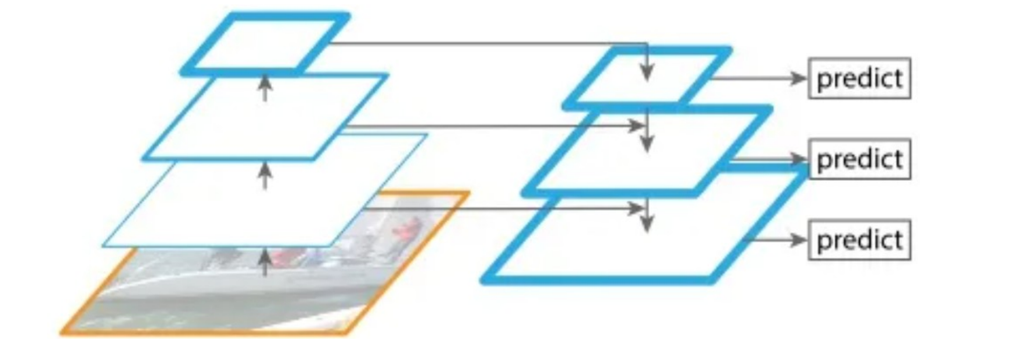

## 羊检测案例（一）：数据、训练与指标

- 任务：从羊场俯拍视频中检测羊的三种姿态（趴卧、站立、饮食），用于健康与福利监测
- **数据四原则**：多样性（角度、背景、光照）、标签准确性、数据量、平衡性
- 过拟合（泛化差）：噪声过大、数据太少、标签错误、参数太多 → 增加数据与数据增强、降低模型复杂度
- 欠拟合：模型复杂度低、特征少 → 增加特征与模型容量
- 数据划分：训练集拟合参数、验证集调超参、测试集只评泛化（不参与调参）
- 训练技巧：
  - 迁移学习：用 COCO 预训练权重初始化，小数据集时冻结更多层，大幅缩短训练时间
  - 抽帧要控制间隔，避免相邻帧高度相似造成信息泄漏
  - 学习率预热与衰减：初期小学习率稳定训练，末期低学习率降低 loss 振荡

## 羊检测案例（二）：结果与工程解读

- 评价指标：查准率 $P$、查全率 $R$、$F_1$、AP／mAP；NMS 按 IoU 阈值去重
- 结果解读：置信度 0.27–0.37 的框多为遮挡与重叠的困难样本
- 工程判断：养殖场更怕漏检，取 β>1；工业质检按缺陷后果定阈值
- 下游决策：趴卧时长异常 → 疾病、发情、拥挤预警 → 饲养管理

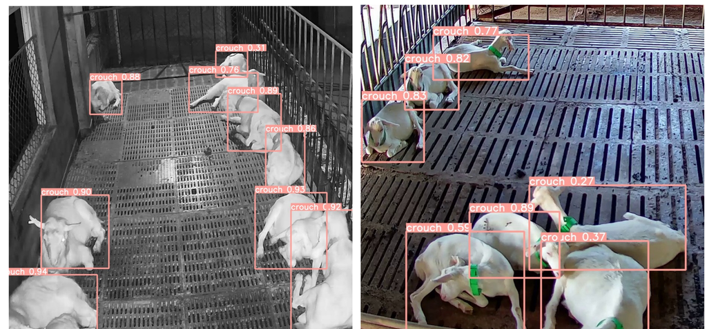

## 视觉检测的工程链：从采集到监控

- 五个环节不是流水线，而是闭环：监控发现漂移，回到采集与标注
- 每一环都要有版本：数据版本、模型版本、参数版本
- 交付物不是“一个模型”，而是“模型 + 规范 + 记录”
- 先定成像方案再选网络：图不清楚，换多大的模型都没用
- 标注规范要写到“什么算缺陷、边界画到哪”

| 环节 | 关键动作 | 交付物 | 失败信号 |
| --- | --- | --- | --- |
| 采集 | 光源、镜头、曝光、同步 | 成像规范与样张库 | 对比度不足、过曝 |
| 标注 | 缺陷定义、边界、复核 | 标注规范与数据集版本 | 两人标法不同 |
| 训练 | 划分数据、增强、迁移 | 模型与指标报告 | 测试集被调参污染 |
| 部署 | 导出模型、节拍联调 | 推理服务与回退方案 | 实验室快、现场慢 |
| 监控 | 抽检漏检率、漂移告警 | 运行日志与再验证记录 | 换料后指标下降 |

- 一句话：能复现的检测，才是可交付的检测

## 视觉检测的三类失效模式

- 两个基本指标：漏检率 $p_{FN}=N_{FN}/(N_{FN}+N_{TP})$，过杀率 $p_{FP}=N_{FP}/(N_{FP}+N_{TN})$
- 指标要按缺陷类别分别统计，平均值会掩盖致命类别
- 现场先问“上次换料后复验了吗”，再谈模型
- 漏检与过杀是一对代价：阈值往哪边挪，另一边就涨
- 复验不是补丁，是把模型的不确定性交给人判断

| 失效模式 | 典型成因 | 现场信号 | 对策 |
| --- | --- | --- | --- |
| 漏检 | 对比度低、遮挡、阈值偏高 | 客户投诉与退货回查 | 降阈值、加复核、补样本 |
| 误检 | 反光、油污、背景纹理 | 复检率上升、产能下降 | 分区掩膜、多光源、二次分类 |
| 域偏移 | 换料、换季、镜头污染 | 换批后指标下降 | 定期再验证、在线监控 |
| 标注漂移 | 标准变更、人员更替 | 同一图两次判定不同 | 标注规范、一致性抽检 |

- 一句话：模型不会突然变坏，是数据先变了

## 案例二：图神经网络预测裂纹

- 对象：PMMA 试件蠕变，光学显微镜与 CCD 沿试件中线每隔 1 mm 拍摄银纹图像
- 问题：裂纹形态的复杂度如何量化，能否用图像直接预测盒维数
- 量化：盒维数 $D_H=\dfrac{\ln N(r)}{\ln(1/r)}$ 把“复杂度”变成一个标量
- 转图：图像划为 14×14 网格，网格为节点，水平或垂直相邻才连边
- 为什么用图：空间邻接被显式写进邻接矩阵，节点特征随时刻变化
- 模型：线性嵌入 → GATv2Conv → 自注意力 → 全局平均池化 → 回归
- 结果：盒维数预测的 MSE 均小于 0.008，长时间段误差更小
- 风险：数据只覆盖有限时长，外推到寿命预测要另做验证

## GNN 建模流程：图、特征与训练

- 图构建：节点为 14×14 网格的格子（196 个），边为水平／垂直相邻；用 edge_index 存 source 与 target
- 节点特征：网格内的像素值，输入维度记为 node_features
- 标签：盒维数归一化后的标量，回归任务输出一个值
- 模型：线性嵌入 → GATv2Conv（DropEdge 正则）→ 自注意力 → 全局平均池化 → 两个线性层
- 训练：固定随机种子 12345，打乱后划分训练／测试
- 评估：测试集 MSE 与残差分布，课件结果均小于 0.008
- 可复现：种子、划分、归一化参数都要版本化，否则结果无法复算
- 一句话：图把“谁和谁相邻”变成模型能读的输入

## 案例三：振源识别与减振优化

- 对象：Q034ZZ 辊道式抛丸机，抛丸器 Q6916AT，电机 Y132S、7.5 kW、50 Hz
- 采集：加速度传感器 16g、500 mV/g，采样率 1 ksps 与 5 ksps 对比
- 方法：FFT／STFT → 单源域筛选 → DBSCAN 估计源数 → 重构源信号
- 结论：空载下主要有两个源，基频来自电机，倍频来自叶轮不平衡
- 闭环：识别 → 定位 → 改进 → 同测点、同采样率复测验收

| 振源 | 特征 | 对策 | 验收 |
| --- | --- | --- | --- |
| 电机 | 基频 50 Hz 为主 | 低振动电机、隔振安装 | 基频幅值下降 |
| 叶轮不平衡 | 倍频突出 | 动平衡、对中、装配 | 倍频降且无新峰 |
| 钢丸冲击 | 随负载变化、空载可对比 | 丸量与抛射参数优化 | 空载与负载对比 |
| 动静件摩擦 | 高频、时变 | 间隙检查、轴承维护 | 高频能量回落 |

- 一句话：减振不是加隔振垫，而是先找对源

## 案例四：焊缝与表面缺陷检测

- 四条常规无损检测：射线 RT、超声 UT、磁粉 MT、渗透 PT，各有适用与盲区
- 视觉擅长表面，内部缺陷要靠射线与超声，没有一种方法通吃
- 安全件（焊缝、承压件）的判据由标准与规程给定，不能只看置信度
- 同一缺陷可能有多种方法可检，选方法要看取向与位置
- 检测记录要能追溯到人员、设备、参数与标准版本

| 缺陷 | 成像方法 | 判据 | 难点 |
| --- | --- | --- | --- |
| 气孔、夹渣 | X 射线 | 形状、密度、位置 | 微小气孔与噪声混淆 |
| 未焊透、裂纹 | 超声、相控阵 | 回波幅值与当量 | 取向敏感、需选角度 |
| 表面裂纹 | 磁粉、渗透 | 磁痕或显示迹 | 只适用铁磁或开口缺陷 |
| 咬边、余高 | 视觉、激光轮廓 | 尺寸与公差 | 反光、弧光、飞溅 |
| 划痕、凹坑 | 明场、暗场、同轴光 | 对比度与面积 | 材质与油污干扰 |

- 一句话：先选对物理量，再谈算法

## 案例五：排产与调度优化

- 约束要素：物料、设备、工具与工装、人员；排产是在约束里找顺序
- 两种排法：正排尽量往前，产能利用高但可能积压；倒排尽量靠后，库存低但前期闲置
- 四条简单规则：最短工期、最早交期、工期与交期距离、CR 值（越小越急）
- 算法四代：约束理论有限产能 → 规则与线性规划 → 遗传、退火、蚁群 → 智能算法加多 Agent
- 目标不是“最优”，而是在交期、负荷、库存、成本之间取可行解
- 与 MES 的分工：APS 排“应该怎么做”，MES 报“实际做到哪”
- 一句话：排产是把约束翻译成顺序，异常来了再重排

## 数字孪生与虚拟调试

- 五维模型：物理实体、虚拟实体、服务、数据、连接
- 与仿真软件的区别：模型随实测数据持续修正，形成闭环
- 虚拟调试：机械、电气、控制模型联调，用信号映射替代实物接线
- 调试内容：节拍与干涉、I/O 逻辑、安全联锁、故障注入
- 价值：把现场调试前移，减少撞机与停线风险
- 前提：模型置信度与信号映射完整；模型不准，结论也不准
- 一句话：孪生不是三维动画，是能对得上信号的模型

## 工业互联网平台与数据中台

- 平台三层：IaaS、PaaS、SaaS；PaaS 沉淀机理模型与数据服务
- 数据中台四步：采集 → 治理（口径、主数据、质量）→ 资产（主题域）→ 服务（API、指标）
- 平台与中台的分工：平台管连接与运行，中台管口径与复用
- 纵向集成不是把数据都搬到云上，而是让每层拿到该拿的数据
- 接口标准（如 OPC UA）决定集成成本，别到后期才谈

| 层级 | 对象 | 典型系统 |
| --- | --- | --- |
| L0 现场 | 传感器、执行器、机床 | 采集与驱动 |
| L1 控制 | PLC、运动控制 | 逻辑与闭环 |
| L2 监控 | 产线、单元 | SCADA、HMI |
| L3 执行 | 车间、工单、质量 | MES、WMS、LIMS |
| L4 经营 | 企业、供应链 | ERP、PLM、CRM |

- 一句话：先统口径，再谈智能

## 边缘智能与实时控制

- 时延预算：$t_{total}=t_{acq}+t_{infer}+t_{comm}+t_{act}$
- 三层实时：硬实时（控制闭环）、软实时（报警与分拣）、非实时（分析与训练）
- 边缘：低时延、数据不出厂，但算力受限、运维分散
- 云：弹性算力、集中训练与治理，但时延与网络不可控
- 分工：云上训练与治理，边缘推理与控制；模型下发要版本与回滚
- 确定性：TSN 与工业以太网解决抖动，无线要评估丢包与切换
- 安全：边缘设备是攻击面，要有白名单、签名与隔离
- 一句话：控制回路里，晚到的正确答案等于错误答案

## 大模型在制造中的三类应用

- 能力边界：擅长起草与检索，不擅长保证事实正确
- 三种用法：检索增强（RAG）、微调、工具调用；制造场景优先 RAG 加工具
- 一条纪律：生成 → 校核 → 签字，签字人负责
- 数据边界：图纸、工艺、客户资料不出内网
- 提示词要写清角色、输入范围与输出格式，减少来回修改

| 场景 | 输入 | 输出 | 人的角色 |
| --- | --- | --- | --- |
| 工艺知识问答 | 工艺文件、标准、8D | 带出处的答案与检查表 | 提问、核对、定稿 |
| 程序与脚本 | 设备手册、接口说明 | PLC 或数据处理草稿 | 仿真验证、上机试跑 |
| 文档初稿 | 模板、检测记录 | 8D、PPAP、作业指导书草稿 | 补数据、签字 |
| 设计与 DFM | 图纸、公差、材料 | 问题清单与改进建议 | 取舍、承担设计责任 |

- 一句话：大模型是助手，不是签名人

## 大模型的风险与验证

- 验证四件套：领域评测集、引用可追溯、人工复核抽样、上线灰度与回滚
- 评测集要含“不知道”的题，考察拒答与求助，而不只看答对率
- 日志要记录模型版本、提示词、检索来源、输出与签字人
- 上线前先做小范围影子运行，把模型输出与人工结果并排比对
- 红队测试：让不了解项目的人专门找能骗过模型的输入

| 风险 | 表现 | 验证手段 | 责任 |
| --- | --- | --- | --- |
| 幻觉 | 编造标准号、参数、引用 | 强制引用、黄金题集抽测 | 使用者与审核人 |
| 泄露 | 图纸工艺进外部模型 | 内网部署、脱敏、最小权限 | 企业与 IT |
| 版权与来源 | 生成内容来源不清 | 来源登记、许可审查 | 企业法务 |
| 不稳定 | 同一问题答案不同 | 固定版本、模板化提示 | 开发者 |
| 责任不清 | AI 起草、无人核对 | 签字链与日志留痕 | 管理者 |

- 一句话：不能验证的生成，不能进工艺文件

## 智能设计的评价：效果、成本、可靠性

- 效果指标必须和代价一起看：漏检与过杀不可同时最优
- 成本要算全生命周期，标注与运维常被低估
- 可靠性看最差批次，不看平均值
- 验收要写进合同：指标、测试集、复验周期、责任
- 同一指标在不同测试集上不可比，验收要固定测试集与口径

| 维度 | 指标 | 判据 |
| --- | --- | --- |
| 效果 | 漏检率、过杀率、F1、mAP | 按缺陷类别分别达标 |
| 成本 | 开发、标注、算力、运维 | 投资回收期 $T=I/N$ 可接受 |
| 可靠性 | 重复性、漂移、可用率 | 换料换季复验仍达标 |
| 体系 | 与 SPC／CPK、FMEA、8D 的接口 | 纳入现有质量体系 |

- 一句话：能被验收的指标，才是项目指标

## 智能设计项目的实施路径

- 三条纪律：先定判据再选算法；先有数据再谈模型；先小后大
- 组织：工艺、质量、IT、设备、供应商五方同桌，缺一方就会在集成阶段返工
- 失败常见原因：目标写成“上 AI”，没有基线也没有责任人
- 立项书要写“不做什么”，否则范围会越做越大
- 试点验收由质量与工艺签字，不由项目组自评

| 阶段 | 关键动作 | 交付物 | 判据 |
| --- | --- | --- | --- |
| 诊断 | 瓶颈、缺陷谱、数据 | 问题清单与基线 | 基线可测量 |
| 立项 | 场景、指标、责任人 | 立项书与验收口径 | 指标可验收 |
| 试点 | 单工位、单工序、小批量 | 试点报告与数据集 | 达标且可复现 |
| 集成 | 与 MES、QMS 接口 | 接口规范与作业指导书 | 现场人员会用 |
| 推广 | 多线复制、运维与再训练 | 运维手册与版本制度 | 复制周期可控 |

- 一句话：智能化项目失败，多半败在立项不在算法

## 案例：一条产线的智能化改造

- 说明：以机加工产线为对象的**教学案例**，只给方案框架，不引用具体企业数据
- 顺序：先做看得见的检测与监测，再做排得顺的排产，最后做调得快的孪生
- 每一步都要有基线、验收人与回退方案
- 人的安排：检测员转复核与标注，班组长学看板与异常处置
- 改造前先录现状视频与基线数据，否则验收时说不清改善了没有

| 改造点 | 问题 | 技术 | 验收 |
| --- | --- | --- | --- |
| 上料与外观 | 人工目检漏检 | 视觉检测与剔除 | 漏检率与过杀率达标 |
| 刀具与主轴 | 突发故障停机 | 振动监测与预警 | 预警提前量与误报率 |
| 排产 | 插单频繁、交期失控 | APS 与 MES 反馈 | 交期达成率与在制品 |
| 调试与换型 | 换型调试时间长 | 数字孪生虚拟调试 | 换型时间与撞机次数 |
| 数据 | 报表口径不一 | 平台与数据中台 | 口径统一、可追溯 |

- 一句话：改造的是产线，验收的是指标，改变的是岗位

## 本部分小结：从模型到责任链

- 一条主线：物理信号 → 数据表示 → 模型 → 工程判据 → 现场动作
- 五个案例：视觉质检、GNN 裂纹、振源识别、焊缝检测、排产优化
- 四项基础设施：数字孪生、工业互联网与中台、边缘智能、大模型
- 三把尺：效果、成本、可靠性；一条路径：诊断—立项—试点—集成—推广
- 与伦理的接口：漏检谁负责、数据是谁的、模型错了怎么办
- 复习提示：能画出这条链并说清每环的判据，就能答大部分综合题
- 一句话：智能设计不是“上模型”，是把判断变成可验收的责任链

## 推导留给 AI：智能设计应用（汇总）

**推导留给 AI**（先自己推，再让 AI 校验，最后交完整推导）

- ① 给定视场 60 mm × 45 mm、最小缺陷 0.03 mm、工作距离 250 mm、1/1.8″ 靶面（7.2 mm × 5.4 mm），完成相机像素与镜头焦距选型，并说明余量。
- ② 若生产节拍为 0.5 s/件，检测算法需要多少 FPS？边缘推理与云端推理的时延预算如何分配？
- ③ 推导 P、R、F1 与 mAP 的关系，并说明为什么养殖场场景应取 β>1 而安全件质检不能只看 mAP。
- ④ 把 14×14 网格改成 28×28，节点数、邻接矩阵规模与计算量各增加多少倍？
- ⑤ 抛丸器频谱中 400 Hz 与 450 Hz 两个峰分别可能对应什么？设计一个验证实验。

# 第四部分 · 前沿、课程设计与总复习

- 前沿：工业互联网与数字孪生、生成式 AI、协作机器人、柔性制造与个性化定制
- 前沿背后的统一逻辑：从图论、运筹学到图神经网络与大模型的理论路线
- 课程设计指导：选题与交付要求、技术方案五要素、伦理与社会影响分析三步框架、评分与答辩
- 全课程总复习：设计基础、企业系统与 8D、伦理与 AI 伦理的要点与题型

## 前沿趋势：人形、具身与工业大模型

三条主线共用一句判断：能力能否落到真实工位

| 方向 | 能力跃迁 | 工程判据 | 主要风险 |
| --- | --- | --- | --- |
| 人形机器人 | 从固定动作到适应环境 | 一个班次稳定、换型少改线 | 安全、成本、维护 |
| 具身智能 | 从看数据到身体交互 | 能泛化到新工位、失败可停 | 物理后果、数据 |
| 工业大模型 | 从人带知识到模型带知识 | 幻觉可核、数据不出内网 | 责任、泄密 |

- 人形＝双足或轮式底盘＋双臂＋灵巧手，为人设计的环境是理由
- 四个难点：平衡、手部操作、续航、人机共处安全
- 具身＝感知—决策—行动闭环；训练靠仿真预训练＋真实微调
- 大模型＝大算力＋大算法＋大数据；先做问答与报告初稿
- 三条线的共同底座：数据、算力、安全制度与责任划分
- 判断顺序：先场景，再形态，最后选模型
- 一句话：演示看动作，落地看一个班次

## 未来工厂：黑灯工厂与柔性制造

- **黑灯工厂**：无人或少人，可关灯连续运行
- 三个前提：产品成熟、工艺能闭环检测、设备可靠
- 代价：投资高、换型难、异常依赖少数专家
- **柔性制造**：多品种、变批量，换程序、换路线、换批量
- FMS＝加工＋物流＋信息三系统，缺一不可
- 两者张力：黑灯追稳定，柔性追变化
- 统一在“可重构”：产线能改、工装能换、数据能通
- 未来工厂＝少人化＋可重构＋可追溯，不是“无人”
- 人的角色：操作者→监控者、维护者、异常处理者
- 判断：投资回收期与 OEE 是硬约束，示范线不等于量产

## 硬件红利的家底：全国 4,300 家示范

> 上一页看一家工厂能走多远，这一页抬头看全国与全省的盘子——示范已经铺开，下一步拼什么。

| 层级 | 合计 | 国家级口径（相加） | 省级口径（相加） |
| --- | --- | --- | --- |
| 全国 | 4,300 | 2,187＋1,283＋17＋813 | — |
| 山东 | 4,222 | 1,161＋432＋1＋37＝1,631 | 183＋2,332＋76＝2,591 |

**结论：智能制造已经过了“铺设备”阶段，4,300 家的下一场竞争在数据。**

## 前沿背后的统一逻辑：理论路线图

- 上排：图论 → 离散数学 → 运筹学 → 复杂网络（线性代数、概率、微积分支撑）
- 下排：图神经网络 → 知识图谱 → 大模型 → 智能制造系统
- 含义：智能制造是同一套“关系—优化—学习”工具在不同尺度上的应用
- 课程设计要求：说清用了哪条理论链、为什么适合你的问题

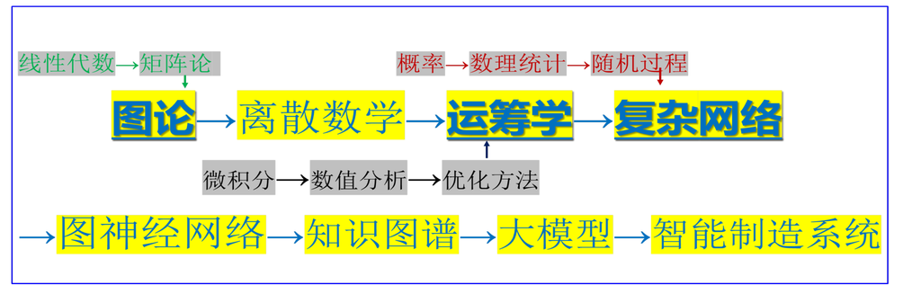

## 技术的社会后果与工程师的选择

| 层面 | 典型后果 | 工程师的选择 |
| --- | --- | --- |
| 就业与技能 | 岗位消失、技能贬值 | 转岗培训、人机分工 |
| 安全与健康 | 事故、职业病 | 冗余、防护、告知 |
| 环境与资源 | 排放、资源耗竭 | LCA、清洁生产、回收 |
| 权力与知情 | 数据控制、算法支配 | 最小必要、可解释 |

## 回望工程与社会：从社会实验到职业责任

| 环节 | 出自 | 核心问题 |
| --- | --- | --- |
| 工程作为社会实验 | 第 1、8 讲 | 谁是被试？谁承担不确定后果？ |
| 责任类型 | 第 8、9 讲 | 因果、角色、法律、道德责任如何划分？ |
| 决策框架 | 第 8 讲 | 后果论、义务论、美德伦理怎么用？ |
| 组织与信任 | 第 9 讲 | 责任模糊化如何破？健康组织文化怎么建？ |
| 技术的社会意义 | 第 10 讲 | 社会价值观如何选择技术路线？国际化与 AI 伦理 |

- 一条线：**社会实验 → 责任类型 → 决策框架 → 组织与信任 → 技术的社会意义**
- 与课程设计的衔接：三步框架（利益相关方与影响分析 → 伦理问题识别与定位 → 伦理决策与辩护）就是把这条线落到一个具体项目
- 一句话：**伦理不是附加的一章，而是把“技术选择”翻译成“可辩护的社会后果”**

## 课程设计：交付物、评分与三步框架

- 交付三件：约 25 页报告、可运行程序、10＋5 分钟答辩
- 五要素：CAD 与工艺、8D 与回收期、CPK 与五大工具、程序、伦理章
- 评分权重：技术 40、数据 20、伦理 20、报告与答辩 20

| 维度 | 权重 | 看什么 | 三步框架对应 |
| --- | --- | --- | --- |
| 技术方案 | 40% | 工艺可行、指标可验证 | 第一步 相关方与影响 |
| 数据与计算 | 20% | 来源可查、结果可复现 | 第一步 影响量化 |
| 伦理与社会 | 20% | 相关方、取舍、辩护 | 第二、三步 |
| 报告与答辩 | 20% | 结构、图表、回答 | 三步贯通 |

- 组内系数：组长 1.0，组员按贡献 0.95 起递减
- 过程分：每周 2 次日志，迟交不计
- 一句话：三步框架走通，伦理 20 分才拿得稳

## 25 页怎么分：一条缺陷讲到底

> 上一页给了交付物与权重，这一页把 25 页拆成能下笔的六章。

| 章 | 内容 | 页数 | 素材／判据 |
| --- | --- | --- | --- |
| 1 | 产品与 CAD：尺寸、公差、加工工艺 | 3 | 三视图、缺陷所在面 |
| 2 | 8D：鱼骨图、5Why、投资回收 | 5 | 第 7 讲的证据链 |
| 3 | 质量分析：CPK、五大工具 | 5 | 第 2 讲算例 |
| 4 | 检测程序：图像处理、软件步骤、PyTorch | 6 | 能跑的最小程序 |
| 5 | 伦理与社会影响 | 4 | 六段写法 |
| 6 | 总结、局限与分工 | 2 | 数据与结论 |

- 页数核对：$3+5+5+6+4+2=25$ 页；程序章最重，占 $6/25=24\%$
- 第 1 章用图交代“缺陷在哪个面、哪个尺寸上”，不给图就没法讨论工艺
- 第 2 章照第 7 讲走：D2 量化、D4 根因、D5 措施、D8 节余，缺一页证据链就断
- 第 3 章至少一个 CPK 算例加一张五大工具对照表，别只抄定义
- 第 4 章不求算法新，求“能运行、有输入输出、有评价指标”；第 5 章按六段写法写满 4 页
- 判据：每一章都有数字、图、可复现的数据来源；没有数据的章就是凑页

**结论：25 页不是篇幅，是一套“缺陷—分析—程序—责任”的完整证据。**

## 课程设计选题：十个可做的方向

选题三原则：有数据、有工艺、有取舍

| 方向 | 典型题目 | 方法与数据 | 伦理落点 |
| --- | --- | --- | --- |
| ① 视觉检测 | 零件表面缺陷 | YOLO＋光源选型 | 漏检谁承担 |
| ② 裂纹演化 | 试样裂纹演化 | GNN＋图像数据 | 外推风险 |
| ③ 振源识别 | 抛丸器振动 | 频谱＋盲源分离 | 误判停机 |
| ④ 线平衡 | 装配线节拍 | 节拍、平衡率、ECRS | 劳动强度 |
| ⑤ 工艺优化 | 焊接、机加工参数 | DOE＋CPK | 参数窗口 |

- ⑥ 预测性维护：寿命模型＋备件 EOQ；停机与库存成本
- ⑦ 车间布局：从至表＋AGV 路径；搬运与碰撞安全
- ⑧ MES 追溯：批次、防错、采集；员工数据隐私
- ⑨ 8D 案例：根因与再发防止；责任闭环
- ⑩ 人机协作：力限与速度监控；共处安全

## 伦理与社会影响章：六段写法

| 段 | 写什么 | 对应 |
| --- | --- | --- |
| ① 场景 | 产品、工序、缺陷、边界 | 技术方案五要素 |
| ② 相关方 | 名单、受益受损、知情 | 三步第一步 |
| ③ 问题 | 安全、隐私、公平、责任、环境 | 五类问题 |
| ④ 依据 | NSPE、三框架、AI 两原则 | 第 8–10 讲 |
| ⑤ 取舍 | 备选、代价、止损、审批 | 三步第三步 |
| ⑥ 责任 | 签字人、复核、追溯、指标 | 第 9 讲 |

## 课程设计时间表与答辩流程

以 6 周为例，按校历整体缩放

| 阶段 | 时间 | 交付 | 检查点 |
| --- | --- | --- | --- |
| 组队选题 | 第 1 周 | 题目、数据清单 | 数据能不能拿到 |
| 方案设计 | 第 2–3 周 | 五要素初稿、程序框架 | 工艺与指标 |
| 中期检查 | 第 4 周 | 可跑的最小版本 | 现场演示 3 分钟 |
| 报告定稿 | 第 5 周 | 25 页报告、伦理章 | 六段齐全 |
| 答辩 | 第 6 周 | PPT、演示 | 10＋5 分钟 |

- 答辩 PPT 五段：问题与数据、方案与工艺、结果、伦理、分工
- 陈述 10 分钟（每段 2 分钟），问答 5 分钟
- 问答准备：数据来源、算法失效、成本、谁承担
- 超时扣分，提前一天交 PPT
- 一句话：时间表倒着排，从答辩日倒推数据截止日

## 组内系数：一份课设成绩怎么算

> 上一页讲答辩怎么走，这一页算成绩怎么落——团队分要拆成个人分。
- 分组：原则 4 人一组；小组系数组长 1.0，组员依次 0.95、0.85、0.80、0.80、0.75、0.75，人少按序取前几档
- 折算：个人得分＝小组报告分×个人系数；4 人组系数和 $1.0+0.95+0.85+0.80=3.60$
- 算例：小组报告 84 分，四人的个人分依次为 $84\times1.0=84.0$、$84\times0.95=79.8$、$84\times0.85=71.4$、$84\times0.80=67.2$
- 差距：组内最高与最低差 $84.0-67.2=16.8$ 分——系数就是把组内贡献差量化
- 过程分：每周 2 次工作日志，交给课代表；迟交不计，日志是系数争议时唯一的凭据
- 组长不是白拿：排期、对外沟通、汇总与催办都要留痕（会议记录、提交记录）
- 判据：系数在组队第一周就公开，期末只按记录折算、不临时改；具体口径以任课教师公布为准

**结论：系数把团队分拆成个人分，唯一能服人的依据是留痕。**

## 总复习一：10 讲知识地图

| 层 | 讲次 · 回答的问题 | 关键工具 | 一句话 |
| --- | --- | --- | --- |
| 定位 | 1 · 为什么做、怎么描述 | 中国制造 2025、图论 | 先看国家与语言 |
| 判据 | 2–3 · 好不好、快不快 | 五大工具、CPK、ECRS | 会算还要会判 |
| 约束 | 4–5 · 安不安全、值不值 | FTA、风险分级、回收期 | 底线与账本 |
| 系统 | 6–7 · 企业怎么跑 | ERP、MES、APS、8D | 工具装进流程 |
| 责任 | 8–10 · 谁承担、怎么辩护 | NSPE、三框架、三步 | 签字的人负责 |

- 一条主线：判据→系统→责任，前者是后者的前提
- 两个出口：考试题型与课程设计三步框架
- 三个接口：质量×成本、系统×8D、伦理×设计
- 复习法：按层走一遍，再按题型走一遍
- 一句话：地图不是目录，是“先看哪一层”

## 总复习二：核心概念 50 词

50 词按五组记：先横着串模块，再竖着抽查

| 模块 | 核心五词 | 补充五词 |
| --- | --- | --- |
| 质量与统计 | 质量、明确需求、PDCA、Cpk、RPN | 隐含需求、七项原则、质量成本、Cp、APQP |
| 工业工程 | ECRS、标准工时、节拍、平衡率、EOQ | 5W1H、瓶颈、七大浪费、平滑指数、人机联合 |
| 安全与环境 | 海因里希法则、FTA、最小割集、$R=L\times S$、LCA | 能量意外释放、双重预防、清洁生产、环评、最小径集 |
| 成本与系统 | 静态回收期、NPV、IRR、ERP、MES | 量本利、制造费用、LCC、PLM、8D |
| 伦理与 AI | 社会实验、NSPE 准则、后果论、算法歧视、可解释性 | 隐含契约、义务论、美德伦理、责任模糊化、知情同意 |

- 用法：不要求背定义，要能连到讲次与一个事实；记不住就回该讲次页
- 讲次：按上表顺序为 1–2、3、4、5–7、8–10 讲
- 抽查：随机点五个词，各说一句定义加一个课程事实

## 总复习三：公式与计算清单

| 主题 | 公式 | 判据／备注 |
| --- | --- | --- |
| CPK | $C_{pk}=\min\left(\frac{USL-\mu}{3\sigma},\frac{\mu-LSL}{3\sigma}\right)$ | $\ge1.33$ 合格；$\ge1.67$ 关键特性 |
| 回收期 | $P_t=I/A$；不等额 $P_t=T-1+\frac{\lvert\sum_{t=0}^{T-1}CF_t\rvert}{CF_T}$ | 从 $t=0$ 起算；$P_t\le P_c$ 可行 |
| NPV | $NPV=\sum_{t=0}^{n}CF_t(1+i_c)^{-t}$ | $>0$ 可行；$=0$ 临界 |
| EOQ | $Q^{*}=\sqrt{2DS/H}$ | $TC^{*}=\sqrt{2DSH}$；单位一致 |
| 风险 | $R=L\times S$ | 分级管控，不是精确值 |
| 线平衡 | $T_{\mathrm{takt}}=T_{\mathrm{avail}}/Q$；$N_{\min}=\left\lceil\sum t_i/T_{\mathrm{takt}}\right\rceil$ | 平衡率 $=\frac{\sum t_i}{N T_{\max}}$ |

- 六个式子一个套路：写定义、代数据、对判据
- CPK 的 $\sigma$ 用组内估计（$\bar R/d_2$），不是全体标准差
- 一句话：公式给答案，判据给结论

## 总复习四：案例分析答题框架

| 步骤 | 要写什么 | 句式／判据 |
| --- | --- | --- |
| ① 事实 | 时间、主体、关键动作 | “某年某方做了什么” |
| ② 问题 | 争点：安全、知情、责任 | “争点是……而非……” |
| ③ 依据 | 准则条款、法条、公式 | “按 NSPE 第 1 条……” |
| ④ 方案 | 备选、代价、止损 | “若选 A，代价是……” |
| ⑤ 评价 | 可公开、可逆、可接受 | “我判断……理由是……” |

- 五步对应三步框架：事实与问题→识别，依据→定位，方案与评价→辩护
- 案例素材：凯悦、737 MAX、COMPAS、甬温线
- 每步一句，不铺陈；阅卷找结构与依据
- 一句话：案例题不是讲故事，是把事实装进框架

## 总复习五：论述题答题框架

| 段落 | 写什么 | 分值 | 禁忌 |
| --- | --- | --- | --- |
| 概念 | 定义与判据 | 2 | 写成名词解释 |
| 分析 | 维度展开、因果链 | 4 | 只列点不展开 |
| 案例 | 一个案例对上维度 | 3 | 堆三个案例 |
| 结论 | 判断＋条件＋边界 | 1 | 模棱两可 |

- 开头：“这个问题的实质是……，可从三个维度看”
- 分析段：每点一句判断＋一句解释，用“第一、第二、第三”
- 结尾：“因此在……条件下，我倾向于……；若……则……”
- 10 分题约 400–500 字，宁短勿散
- 一句话：框架决定及格，案例决定分数，判断决定档次

## 总复习六：计算题易错点

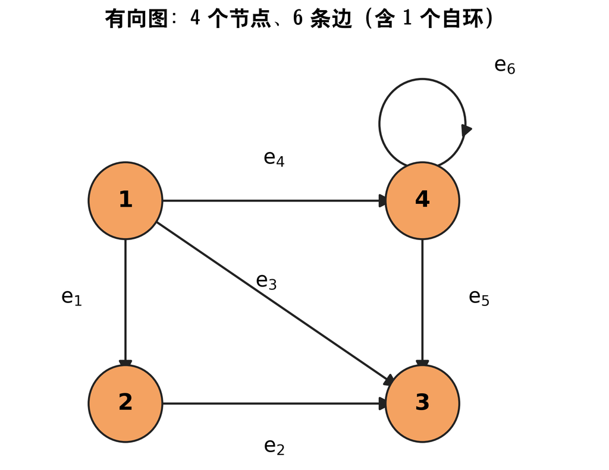

- 邻接矩阵：行是起点、列是终点；自环记 1，无向图才对称
- 度中心性：$C_D(i)=k_i/(n-1)$；有向图先声明出度还是总度
- 拉普拉斯：$L=D-A$，行和为 0，必有零特征值
- CPK：$\sigma$ 用组内估计；单侧规格只算一侧
- 回收期：从 $t=0$ 起算；插值分子取上年累计的绝对值
- NPV／EOQ：折现到 0 年；$D$、$S$、$H$ 时间单位一致

## 总复习七：选择题高频考点

| 考点 | 真题问法 | 判据 |
| --- | --- | --- |
| 复杂网络性质 | 哪个不是网络性质 | 自组织、自相似、吸引子；图论不是 |
| 改善四原则 | 工业工程改善原则 | ECRS；PDCA 是循环，不是四原则 |
| 五大工具 | 哪个不属于五大工具 | APQP、FMEA、MSA、SPC、PPAP；SWOT 不是 |
| 法人责任 | 谁承担无限责任 | 个人独资；公司股东以出资为限 |
| MES 目标 | 哪个不是 MES 目标 | 防错、改善、追溯；销售不是 |
| CPK 判读 | CPK＝1.45 代表 | A 级：状态良好，保持现状 |

- 节点度：数相连边；有向图分出入度，别把边数当度
- 深度学习平台：PyTorch 是；SolidWorks、Abaqus、Origin 不是
- 图像卷积核：算术平均、高斯、LoG、Sobel，看权重形状
- 记忆法：字母题记全称，数字题记门槛，归属题记边界
- 一句话：选择题考边界，不考深度

## 期末应试策略与时间分配

六卷结构一致（单选 30＋简答 30＋论述 30＋计算 10），以 120 分钟为例

| 题型 | 分值 | 时间 | 策略 |
| --- | --- | --- | --- |
| 单选 10 题 | 30 | 25 分钟 | 先做有把握的，标记存疑 |
| 分析简答 6 题 | 30 | 30 分钟 | 定义＋三点＋例子 |
| 论述 3 题 | 30 | 45 分钟 | 框架—案例—判断 |
| 计算 1 题 | 10 | 12 分钟 | 公式、代入、单位、判据 |
| 检查 | — | 8 分钟 | 补漏、核对计算与填涂 |

- 开场 2 分钟通览全卷，先易后难，不恋战
- 简答按点给分：五条短句胜过一段长文
- 论述先写提纲，标题化分段，每段一个判断
- 计算写四行：公式、代入、结果、判据
- 一句话：时间是分数，分配比速度重要

## 常见失分点与检查清单

| 失分点 | 典型表现 | 纠正 |
| --- | --- | --- |
| 概念混淆 | 安全事故写成安全责任事故 | 背四条判据：预见、告知、检查、纠正 |
| 只给结论 | 论述没有分析过程 | 每点“判断＋解释” |
| 计算无过程 | 只写答案、无单位 | 公式、代入、单位、判据 |
| 案例张冠李戴 | 凯悦写成 737 MAX | 一案例记三要素：时间、主体、失效 |
| 伦理喊口号 | 没有相关方与取舍 | 六段结构，写出反对者 |
| 时间失控 | 前面写太满，后面空白 | 按分值配时，留 8 分钟 |

- 交卷前查三样：姓名学号、答题卡、计算单位
- 简答查“有没有定义”，论述查“有没有判断”
- 一句话：会做的题不丢分，就是高分

## 课程总结：从工具到责任

| 层 | 问句 | 代表工具 |
| --- | --- | --- |
| 工具 | 怎么算 | CPK、NPV、FTA、EOQ |
| 判据 | 算到多少算好 | 1.33、回收期、风险分级 |
| 责任 | 谁承担、凭什么 | NSPE、三步框架 |

- 三层能力：会算、会判、敢签字
- 三个转变：单点→系统、技术→社会、正确→可辩护
- 工程师底线：不隐瞒、不越界、不甩锅
- 课程设计就是把三层走一遍：算得出、判得对、说得清
- 一句话：工具决定能做什么，责任决定敢不敢签字

## 本部分小结：把判断带走

- 前沿：人形、具身、工业大模型，判断落在真实工位
- 工厂：黑灯是结果，柔性是能力，少人化＋可重构
- 课程设计：三件交付、五要素、三步框架、伦理六段
- 复习：一张地图、50 词、六个公式、两套答题框架
- 考试：按分值配时，先框架后细节，判断比字数重要
- 一句话：把“工具—判据—责任”这条线带走
- 下一步：按时间表交材料，答辩见

## 推导留给 AI：前沿、课程设计与总复习（汇总）

**推导留给 AI**（先自己推，再让 AI 校验，最后交完整推导）

- ① 自查课程设计：把三步框架套到你的选题上，写出利益相关方名单与至少三个伦理问题，并标注对应的伦理原则。
- ② 用一句话说清工业互联网、数字孪生、MES 三者的关系；再用一个工厂场景举例说明三者的数据流。
- ③ 生成式 AI 用于编写 8D 报告时，哪些步骤可以交给它、哪些必须人工完成？给出理由与校核清单。
- ④ 从 10 次课中任选两个模块，说明它们如何共同支撑一个制造问题的解决（例如“质量工具 + 8D”“成本 + 安全”）。
- ⑤ 用“框架—案例—判断”三段式写一段 200 字的论述：算法决策出错时谁应当负责？

# 第五部分 · 例题、讨论与 AI 提问

- 三道典型例题：投资回收期计算（计算题）、CPK 判读与 8D 步骤（简答题）、图论矩阵（论述题）
- 两次课堂讨论：国际化肥料厂、漏检代价由谁承担
- 三道例题覆盖考试的三种题型，答案已用 Python 复核
- 讨论题没有标准答案，要求给出立场、依据与反驳

## 历年真题：法人责任与图像处理

**单选（2020—2022 各卷）** 下列公司中法人承担无限责任的是（ ） A. 股份公司 B. 国有独资公司 C. 集体所有制企业 D. 个人独资公司

- 答案 **D**：个人独资企业投资人承担**无限责任**；公司制以出资额为限

**简答（2020 B / 2021 B / 2022 B）** 列举工件裂纹图像处理中的 5 个方法，并简要介绍其作用

- 灰度化、滤波去噪、边缘检测（Sobel／Canny）、阈值分割、形态学处理——各配一句话
- 与第三部分机器视觉检测同一套流程：预处理 → 增强 → 分割 → 特征

## 例题 1：静态投资回收期（计算题）

**题目**：某项目现金流量如下表（单位：万元），计算其静态投资回收期。

| 年度 | 1 | 2 | 3 | 4 | 5 | 6 | 7 | 8 |
| --- | --- | --- | --- | --- | --- | --- | --- | --- |
| 现金流入 | 0 | 0 | 800 | 1200 | 1200 | 1300 | 1300 | 1200 |
| 现金流出 | 600 | 900 | 500 | 700 | 700 | 700 | 700 | 700 |
| 净现金流量 | -600 | -900 | 300 | 500 | 500 | 600 | 600 | 500 |
| 累计净现金流量 | -600 | -1500 | -1200 | -700 | -200 | 400 | 1000 | 1500 |

- 判据：累计净现金流量由负转正的年份为第 6 年
- 计算：$P_t=(6-1)+\dfrac{|-200|}{600}=5+\dfrac{200}{600}=5.33$ 年
- 结论：静态投资回收期 5.33 年，基准回收期若为 5 年则项目不可行

## 例题 2：CPK 判读与 8D 步骤（简答题）

**第 1 题（单选）**：工厂的过程能力指数 CPK 为 1.45，代表（ ）

- A. 无缺点，考虑降低成本 B. 状态良好，维持现状 C. 改进为 A 级 D. 制程不良较多
- 判读：CPK ≥ 1.67 特级（无缺点，考虑降低成本）｜1.33 ≤ CPK < 1.67 一级（状态良好，维持现状）｜1.0 ≤ CPK < 1.33 二级（改进为 A 级）｜0.67 ≤ CPK < 1.0 三级（制程不良较多）｜CPK < 0.67 四级（能力不足）
- 答案：**B**

**第 2 题（简答）**：列举 8D 方法中的 5 个步骤并简述其内容。

- D1 成立小组：跨职能团队，明确组长与职责
- D2 问题描述：用 5W2H 描述现象，量化不良率与影响
- D4 根本原因：5Why、鱼骨图、FMEA 验证真因
- D5 永久纠正措施：针对根因，验证有效性
- D7 预防再发：更新 FMEA、控制计划与作业标准，形成责任闭环

## 例题 3：邻接矩阵、度中心性与拉普拉斯矩阵（论述题）

**题目**：无向图 $G=(V,E)$，顶点 $V=\{1,2,3,4,5,6\}$，边 $E=\{(1,2),(1,3),(2,3),(2,4),(3,4),(4,5),(5,6)\}$。写出邻接矩阵与拉普拉斯矩阵，并计算各节点的度中心性。

- 邻接矩阵 $A$（行列为节点 1–6）：

|  | 1 | 2 | 3 | 4 | 5 | 6 |
| --- | --- | --- | --- | --- | --- | --- |
| 1 | 0 | 1 | 1 | 0 | 0 | 0 |
| 2 | 1 | 0 | 1 | 1 | 0 | 0 |
| 3 | 1 | 1 | 0 | 1 | 0 | 0 |
| 4 | 0 | 1 | 1 | 0 | 1 | 0 |
| 5 | 0 | 0 | 0 | 1 | 0 | 1 |
| 6 | 0 | 0 | 0 | 0 | 1 | 0 |

- 度：$d=[2,3,3,3,2,1]$；度中心性 $DC_i=d_i/(N-1)=[0.4,0.6,0.6,0.6,0.4,0.2]$，节点 2、3、4 最重要
- 拉普拉斯矩阵 $L=D-A$：$L_{ii}=d_i$，$L_{ij}=-1$（相邻），其余 0；$L$ 每行和为 0，最小特征值为 0

## 课堂讨论（一）：肥料厂该不该建

**情境**：某公司在 X 国建肥料厂。产品让当地农民买得起肥料，但工厂排放标准低于公司本国标准，污染物使周边居民患病。X 国没有相应排放法规。

- 分组立场（各 3 分钟陈述，2 分钟互相质询）：
  - 甲方：按当地法规建，能解决饥饿问题，不建也有别国公司来建
  - 乙方：按本国标准建，否则不参与；宁可失去项目也不降低底线
  - 丙方：中间方案——可普遍化的底线（居民健康）+ 本地化的技术路线与补偿机制
- 讨论要求：每个立场必须回答三个问题
  - 谁受益、谁受损？受损者是否知情、能否选择？
  - 最坏情况是什么？发生后谁负责、如何补救？
  - 你的底线是什么？为什么这条底线可以普遍化？

## 课堂讨论（二）：漏检的代价由谁承担

**情境**：某汽车零部件厂上线 AI 视觉质检，替代 6 名质检员。系统漏检率 0.3%，人工为 0.1%。一次漏检导致下游装配后整车召回，损失 800 万元。

- 分组讨论：
  - 责任链：算法供应商、设备集成商、工厂质量部门、操作者、最终用户
  - 合同问题：验收标准里的漏检率是否为“保证值”？超标如何赔偿？
  - 管理问题：谁来复核模型输出？复核记录保存多久？
  - 人的问题：被替代的 6 名质检员如何转岗与培训？
- 讨论要求：画出一条责任链，并在每一环标注“证据是什么”

## 推导留给 AI：综合讨论（汇总）

**推导留给 AI**（先自己推，再让 AI 校验，最后交完整推导）

- ① 把肥料厂案例改写成一份 300 字的伦理备忘录：事实、相关方、可选方案、建议与理由、最坏情况预案。
- ② 漏检案例中，如果合同没有约定漏检率，你认为应当由谁承担 800 万元损失？给出三种可能的法律与伦理依据。
- ③ 用 COMPAS 案的逻辑分析“车间员工绩效 AI 评分系统”：它可能产生哪类歧视？如何检测？
- ④ 把三次讨论的结论汇总成一张“三步框架”检查表，用于课程设计自查。

## 历年真题：本讲相关题的分布

[output not shown]

- 一句话：**先背三张清单再刷六卷原卷，这些分背了就有、不背就丢**

## 真题：图像处理五种方法的给分点

- 题面（2020B／2021B／2022B，5 分）：列举裂纹图像处理 5 个方法及作用
- 给分：每方法 1 分，名称与作用各半；只写名称最多 2.5 分

| 方法 | 作用（一句话） | 给分点 | 常见失分 |
| --- | --- | --- | --- |
| 灰度化 | 三通道按亮度加权成单通道，降维提速 | 写出加权或“减少计算量” | 只写“变黑白” |
| 滤波去噪 | 均值／中值／高斯抑制噪声，改善后续分割 | 举一类滤波器并说明抑制何种噪声 | 与图像增强混为一谈 |
| 边缘检测 | Sobel 一阶差分／Canny 多步，定位裂纹轮廓 | 给出算子名与“梯度”依据 | 只写“Canny 最好” |
| 阈值分割 | 按灰度阈值分前景背景，Otsu 自动取阈 | 写出二值化与阈值选取 | 漏写“二值化” |
| 形态学处理 | 腐蚀膨胀与开闭运算，去毛刺、连断线 | 开运算去噪点、闭运算补断裂 | 只写“形态学”不写算子 |

- 一句话：**方法名 → 作用 → 解决哪一步，五个方法串成流程**

## 真题：深度学习算法与卷积核识别

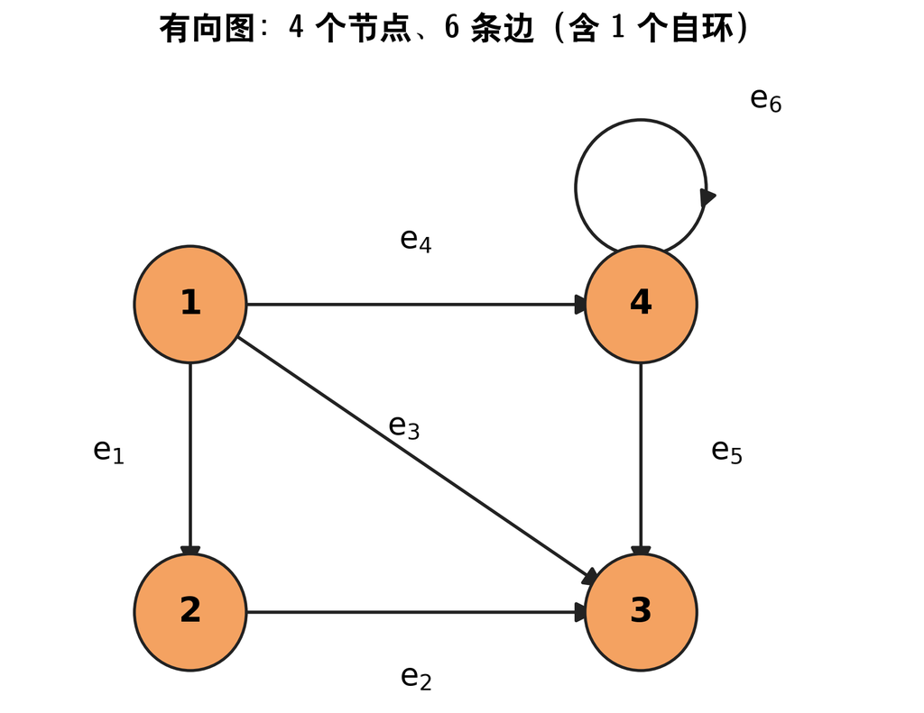

- 单选（2020A／2021A／2022A，3 分）：卷面给出一个卷积核矩阵，问它属于哪种
  - A 算术平均核 B 高斯核 C LoG（Marr-Hildreth）核 D Sobel 核
- 判据：权重全相等且和为 1 → 均值核；中心大四周小、和为 1 → 高斯核；权重和为 0 → 边缘或拉普拉斯类
- 简答（2020A／2021A／2022A，5 分）：列举深度学习的 5 个算法并述优缺点
  - 备选五个：CNN、RNN／LSTM、GAN、自编码器、深度信念网络——各配一句优点一句缺点
- 配图为 2022A 卷第三题（10 分）：邻接矩阵、拉普拉斯矩阵与度中心性
- 读图要点：4 节点 6 边，$e_6$ 为自环——自环计入对角元，出度与入度分开数
- 提醒：六卷只考”识别”，没有”卷积核参数计算”题，计算训练放到下一页

## 计算例题：卷积核与参数量

- 六卷只考“识别”，参数量计算是自编练习，吃透四个参数：长、宽、深、个数
- 公式：$H_{out}=\left\lfloor \dfrac{H_{in}+2p-k}{s}\right\rfloor+1$；参数量 $N=(k^{2}C_{in}+1)C_{out}$

| 层 | 输入与卷积核 | 输出 | 参数量 |
| --- | --- | --- | --- |
| Conv1 | $32\times32\times3$，$k=5$，6 个核 | $28\times28\times6$ | $(25\times3+1)\times6=456$ |
| Conv2 | $28\times28\times6$，$k=3$，16 个核 | $26\times26\times16$ | $(9\times6+1)\times16=880$ |
| 全连接 | $4704$ 个输入，120 个神经元 | $120$ | $4704\times120+120=564600$ |

- 手算：$32-5+1=28$，$76\times6=456$；$28-3+1=26$，$55\times16=880$
- 对比：两层卷积共 1336 个参数，全连接要 56 万——差 400 多倍
- 结论：参数量只由 $k$、$C_{in}$、$C_{out}$ 决定，与图像尺寸无关

## 课堂讨论：AI 会让工程师失业吗

- 情境：三个落地案例都在替代“人做判断”——漏检、裂纹预测、振源识别
- 三立场（各 3 分钟陈述＋2 分钟质询）：
  - 替代论：任务可分解、可标注就能学；成本过临界点后不可逆
  - 增强论：AI 接管重复判断，人转向定义问题、设判据、验收担责
  - 重构论：岗位边界重划，数据治理与模型运维成新岗，旧技能折价
- 每条立场都要落到本讲案例：漏检阈值、裂纹预测、振源识别
- 三问必答：替代的是“任务”还是“岗位”？转型成本谁付？人的不可替代能力是什么？
- 纪律：不用“据说 80% 会消失”这类数字，要用须给出可打开的出处
- 落点：技术内嵌于社会——岗位结果由技术与制度、培训共同决定
- 一句话：**问题不是“会不会失业”，而是“转型成本由谁承担、由谁决定”**

## 课堂讨论：技术中立吗

- 争点：一方说”技术只是工具，用得好坏在人”；另一方说”设计物本身就在替人做决定”
- 三立场：
  - 中立论：技术无善恶，责任全在使用者——“枪不杀人，人杀人”
  - 非中立论：设计物限制或引导行为，默认值就是权力
  - 中间论：原理层面可中立，选择、部署与默认值不中立
- 四条判据（每条要举本讲一个例子）：默认值替谁做了决定？谁能用、谁被排除？失败时谁承担？有没有可替代的设计？
- 理论对接：设计决策”往往不是社会中立的”；技术内嵌于社会
- 辨析三种免责话术：“算法自己学的”“大家都这么干”“用户自己点了同意”
- 一句话：**中立论最危险的地方，是让设计者提前退出责任**

## AI 提问：本讲 5 个延伸问题

- 把课堂结论变成可验证的问题：给数据、要复算、追问反例

| 主题 | 让 AI 做什么 | 追问与核对 |
| --- | --- | --- |
| 卷积核 | 给输入尺寸与核参数，算输出尺寸与参数量 | 先要公式再代入；456、880 自己手算一遍 |
| 深度学习五算法 | 各写一句优点与一句缺点 | 查是否把 CNN 说成”万能”；优缺点必须成对 |
| 技术中立 | 扮演”技术只是工具”的辩护者，与你就 AI 质检辩论 | 复盘哪句是事实、哪句是免责话术 |
| 就业影响 | 找 3 条可核查的就业数据并给出处 | 核对年份、统计口径与样本；打不开的链接不算 |
| 真题模拟 | 按六卷题型出 5 道模拟题并给评分点 | 对照原卷，检查是否超纲、答案是否唯一 |

- 五问对应五块：卷积核、深度学习、技术中立、就业、真题
- 提问三件套：给定数据／要求复算／追问反例；AI 的回答只是初稿
- 核对纪律：来源要能打开、公式要能手算、答案要能对上原卷
- 让 AI 扮演反方时，先给角色与材料范围，否则它会自由发挥、偏离本讲口径
- 小组互评：谁的问题能被第三方按同样步骤复现，谁就得分
- 一句话：**会核对，才敢把 AI 的输出写进报告**

## 考前自测：10 道判断题

1. 技术决定论若成立，伦理评价就失去意义。（√：拦不住的事谈不上责任）
2. 同一问题只有一条路线，社会价值不影响选择。（×：STS 多方案）
3. “效率”完全客观，与把谁算作成本无关。（×：童工曾被算作高效）
4. 跨国经营只要“入乡随俗”，就能回避伦理冲突。（×：滑向标准最低者胜）
5. LCA 的结论不受系统边界划定的影响。（×：范围决定结论）
6. 算法歧视可经代理变量产生。（√：邮编、消费记录可代理）
7. 模型上线后，事故责任可转移给供应商。（×：责任不转移）
8. $3\times3$ 均值核与高斯核的权重之和都为 1。（√：都做加权平均）
9. 卷积层参数量随图像尺寸增大而增大。（×：与尺寸无关）
10. Sobel 等边缘检测核权重之和通常为 0。（√：差分抵消常量）

# 第六部分 · 本讲小结、作业与下讲预告

- 本讲小结：三句话收住技术社会、全球责任与 AI 伦理
- 作业与复习：案例分析、伦理评估、课程设计准备与三轮复习
- 下讲预告：课程设计答辩与课程收尾
- 复习提示：20 个术语、三套例题与答题策略

## 本讲小结：技术社会性、全球责任与 AI 伦理

1. **技术社会性**：工程是带责任的**社会实验**——结果有不确定性、实验对象是真实的人，工程师必须为实验负责；技术路线由社会价值观选择，判断标准是“能否公开辩护”。
2. **全球责任**：华盛顿、悉尼、都柏林三大协议让学位互认，FEANI 与 ISO 让标准互认，但**执业底线不互认**——六类陷阱只能靠普遍原则加本地方案走中间道路。
3. **AI 伦理**：风险沿“数据—模型—应用—社会”逐级放大，偏见、隐私、可解释与问责都能落到指标与流程；**责任不随自动化程度转移**。
- 一条主线：技术内嵌于社会 → 标准与守则划底线 → AI 风险可治理 → 智能设计过工程约束
- 一个判据：能说清“谁受影响、受多大、凭什么”，才叫伦理判断
- 一句衔接：这三句话就是课程设计伦理章的三段——利益相关方、问题定位、决策辩护

## 关键概念清单：20 个术语

| 组 | 四个术语 | 落点 |
| --- | --- | --- |
| 技术与社会 | 社会实验、技术内嵌于社会、技术决定论、批判态度 | 技术怎么选 |
| 全球工程 | 华盛顿协议、文化相对主义、中间道路、六类伦理陷阱 | 标准怎么跨国 |
| 环境伦理 | 可持续、LCA 四步、CERES 原则、环境正义 | 环境责任怎么分 |
| AI 伦理 | 算法歧视、可解释性、权责一致、算法安全 | AI 风险怎么治 |
| 决策与落地 | 利益相关方、三步框架、像素精度、图神经网络 | 判断怎么落地 |

- 会辨析三对：技术决定论／技术乐观主义｜绝对主义／相对主义｜算法安全／算法滥用
- 会算两式：像素精度 $\delta=\mathrm{FOV}/N$；风险 $R=p\times C$
- 抽查：下次课随机抽 5 个术语，各配一句定义与一个本讲事实

## 作业：案例分析、伦理评估与课程设计准备（100 分）

- **一·案例分析（40 分）**：Coppergiant、SyRI、亚马逊招聘三选一，分别用剥削的五个条件、权责一致、歧视三类来源逐条分析，1500 字，注明来源
- **二·伦理评估（35 分）**：用三步框架评一个 AI 质检方案——利益相关方表、五类问题定位、两个备选与取舍，1 页表＋800 字
- **三·课程设计准备（25 分）**：伦理章提纲——利益相关方名单、三条主要风险、两条备选方案与责任分配，附 3 分钟陈述
- 计分只看三条：事实具体（时间／部位／数字）、依据可查（条款／判例／页码）、方案可执行
- 提交：A4 或 PDF，下次课前；案例分析独立完成，设计部分按组提交并附分工

## 期末复习：三轮安排与答疑

| 时间 | 要做的事 | 留下的东西 |
| --- | --- | --- |
| 答辩当周 | 按 10 次课顺序过讲义，标出没学透的模块 | 一份短板清单 |
| 答辩后一周 | 集中答疑 2 学时；三套例题限时做、对给分点 | 三套订正 |
| 考前三天 | 只补短板：错题本＋20 个术语抽背，不刷新题 | 一页错题 |

- 材料：十讲讲义目录、20 个术语页、第五部分三道例题；不另发复习提纲
- 答疑：时间地点发课程群；平时提问随问随答，共性问题下次课统一讲
- 提醒：伦理题按“框架—案例—判断”三段写；计算题公式、代入、单位一个不能省

## 课后阅读与拓展资源清单

| 类别 | 资源 | 主题 | 范围 |
| --- | --- | --- | --- |
| 教材 | 第 4 章 | 技术社会观 | p72–88 |
| 教材 | 第 8 章 | 环境伦理 | p173–186 |
| 教材 | 第 9 章 | 全球化 | p187–205 |
| 课件 | 《工程与社会》 | 4／7／8 讲 | 对照读 |
| 报告 | AI 伦理风险报告 | 两原则八指标 | 全文 |
| 拓展 | 欧盟 AI 法案 | 风险分级 | 选读 |

- 精读：§4.8 批判态度、§8.5 可持续与 LCA、§9.6–9.11 六类陷阱；准则条款见教材附录 p286
- 读法：先案例后正文；术语对照记（social experimentation、stewardship、middle way）
- 提交：1 页笔记，每份材料 1 条要点＋1 个疑问；下次课抽查

## 课程结语：工程师的责任与未来

- **三条不变**：
  - 技术选择就是价值选择：路线一旦定下，后果由使用它的人承担
  - 责任不能外包：包给算法、层级或“当地惯例”，责任仍在工程师身上
  - 判断要能公开辩护：说不出谁受影响、受多大、凭什么，就不是工程判断
- **三个变化**：
  - AI 让影响更快更广：一次模型错误会被复制到所有产线、所有客户
  - 供应链让责任跨境：零件在别国制造、在第三国使用
  - 可持续成为硬约束：碳排放与合规从加分项变成入场券
- 带走三样：一张利益相关方清单、一条可核查的证据链、一个能说“不”的渠道

> 工程师的职业性，不在于会算，而在于算完之后，敢在图纸上签下自己的名字。

## 推导留给 AI：全课程复盘（汇总）

**推导留给 AI**（先自己推，再让 AI 校验，最后交完整推导）

- ① 用一张图把 10 次课串成“判据—流程—关系—学习—伦理”的主线，并标出你所在课题对应的位置。
- ② 从试卷的三种题型中各选一题，先自己限时作答，再用 AI 对照评分标准自查，写出失分点。
- ③ 挑一个你没学透的模块（如 FTA、APS、CPK），让 AI 用“定义—工具—案例—易错点”四段式讲一遍，再自己复述一遍。
- ④ 课程结束前写一份 300 字的自我评估：这门课改变了你对“工程师责任”的哪些看法？举一个具体例子。